# Analysis for Schweizer, et al., Submitted, Thermal acclimation in a non-migratory songbird occurs via changes to thermogenic capacity rate, but not conductance

We start by loading libraries and data.

```r
run_date <- format(Sys.Date(), "%d%b%Y")


# load in all necessary libraries

library(lme4)
library(lmerTest)
```

```r
library(MuMIn)
library(ggplot2)
library(emmeans)
library(dplyr)
setwd("~/Dropbox/chickadee_data/analysis_for_pub")

# load in meta data with information for each sample
bird_meta <- read.csv("~/Dropbox/chickadee_data/data_files/Respirometry_Metadata_simp_26Apr2023.csv")

# made data subsets for each time point
bird_meta_0wk<- bird_meta[bird_meta$Timepoint=="0wk",]

bird_meta_3wk<- bird_meta[bird_meta$Timepoint=="3wk",]

bird_meta_6wk<- bird_meta[bird_meta$Timepoint=="6wk",]
```

First, we’ll do some exploratory analysis to test for effects of **mass** on **BMR** and **SMR**.

```r
anova(lmer(bird_meta$BMR ~ bird_meta$Mass.BMR + (1|bird_meta$ID)))
```

|  | Sum Sq | Mean Sq | NumDF | DenDF | F value | Pr(>F) |
| --- | --- | --- | --- | --- | --- | --- |
| bird_meta$Mass.BMR | 0.0263654 | 0.0263654 | 1 | 22.0531 | 4.547299 | 0.04435036 |

```r
anova(lmer(bird_meta$VO2max ~ bird_meta$Mass.SMR + (1|bird_meta$ID)))
```

|  | Sum Sq | Mean Sq | NumDF | DenDF | F value | Pr(>F) |
| --- | --- | --- | --- | --- | --- | --- |
| bird_meta$Mass.SMR | 4.775101 | 4.775101 | 1 | 19.69679 | 15.0975 | 0.000941079 |

We see that mass has a significant effect on BMR and SMR, so we will include mass as a covariate in our models. Next, let’s test for an effect of **sex** on **BMR** and **SMR**. After including mass as a covariate, we might not expect an effect, since these birds were collected after the breeding season.

```r
anova(lmer(bird_meta$BMR ~ bird_meta$Mass.BMR + bird_meta$Sex + (1|bird_meta$ID)))
```

|  | Sum Sq | Mean Sq | NumDF | DenDF | F value | Pr(>F) |
| --- | --- | --- | --- | --- | --- | --- |
| bird_meta$Mass.BMR | 0.006032739 | 0.006032739 | 1 | 32.34713 | 1.0482480 | 0.3135072 |
| bird_meta$Sex | 0.004425581 | 0.004425581 | 1 | 18.01450 | 0.7689885 | 0.3920747 |

```r
anova(lmer(bird_meta$VO2max ~ bird_meta$Mass.SMR + bird_meta$Sex  + (1|bird_meta$ID)))
```

|  | Sum Sq | Mean Sq | NumDF | DenDF | F value | Pr(>F) |
| --- | --- | --- | --- | --- | --- | --- |
| bird_meta$Mass.SMR | 3.32632069 | 3.32632069 | 1 | 29.19259 | 10.71083 | 0.002739665 |
| bird_meta$Sex | 0.06682247 | 0.06682247 | 1 | 15.19027 | 0.21517 | 0.649322712 |

We do not see a significant effect of sex, so we will not include it as a covariate in our analyses. Do we see a significant effect of **treatment** on **mass**?

```r
model1_mass <- lmer(bird_meta$Mass.BMR ~ bird_meta$Treatment*bird_meta$Timepoint + (1|bird_meta$ID))

anova(model1_mass)
```

|  | Sum Sq | Mean Sq | NumDF | DenDF | F value | Pr(>F) |
| --- | --- | --- | --- | --- | --- | --- |
| bird_meta$Treatment | 0.128705 | 0.1287050 | 1 | 12 | 1.463316 | 2.496953e-01 |
| bird_meta$Timepoint | 3.371757 | 1.6858786 | 2 | 24 | 19.167651 | 1.061026e-05 |
| bird_meta$Treatment:bird_meta$Timepoint | 1.738605 | 0.8693024 | 2 | 24 | 9.883562 | 7.391948e-04 |

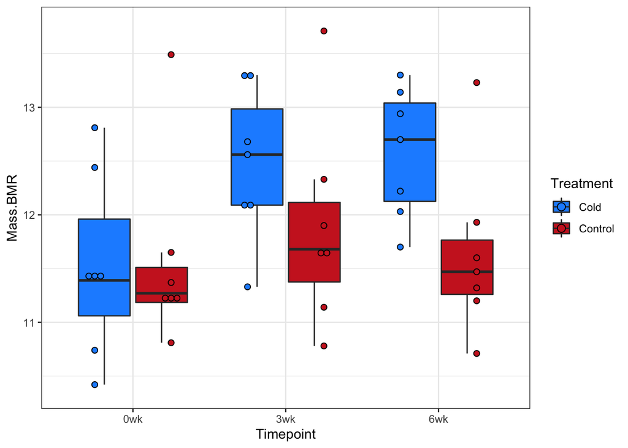

```r
ggplot(bird_meta, aes(x=Timepoint, y=Mass.BMR, fill=Treatment)) +
  geom_boxplot(outlier.shape = NA) + scale_fill_manual(values=c("#1E90FF", "#CD2626")) +  geom_dotplot(binaxis='y', stackdir='center',
  position=position_dodge(1), dotsize = 0.5) + theme_bw()
```

```r
pdf(file=paste("Figure_SX_box_plot_bodyMass_",run_date,".pdf",sep=""),height=6,width=8)
ggplot(bird_meta, aes(x=Timepoint, y=Mass.BMR, fill=Treatment)) +
  geom_boxplot(outlier.shape = NA) + scale_fill_manual(values=c("#1E90FF", "#CD2626")) +  geom_dotplot(binaxis='y', stackdir='center',
  position=position_dodge(1), dotsize = 0.5 ) + ylab("Body mass prior to BMR measurement (g)") + theme_bw()
dev.off()
```

```r
pairs(emmeans(model1_mass, ~Treatment*Timepoint), adjust="BH")
```

```
##  contrast                  estimate    SE   df t.ratio p.value
##  Cold 0wk - Control 0wk     -0.0429 0.432 14.4  -0.099  0.9223
##  Cold 0wk - Cold 3wk        -0.9543 0.159 24.0  -6.020  <.0001
##  Cold 0wk - Control 3wk     -0.3557 0.432 14.4  -0.824  0.5772
##  Cold 0wk - Cold 6wk        -1.0529 0.159 24.0  -6.642  <.0001
##  Cold 0wk - Control 6wk     -0.1143 0.432 14.4  -0.265  0.8517
##  Control 0wk - Cold 3wk     -0.9114 0.432 14.4  -2.112  0.1501
##  Control 0wk - Control 3wk  -0.3129 0.159 24.0  -1.974  0.1501
##  Control 0wk - Cold 6wk     -1.0100 0.432 14.4  -2.340  0.1501
##  Control 0wk - Control 6wk  -0.0714 0.159 24.0  -0.451  0.7573
##  Cold 3wk - Control 3wk      0.5986 0.432 14.4   1.387  0.2799
##  Cold 3wk - Cold 6wk        -0.0986 0.159 24.0  -0.622  0.6749
##  Cold 3wk - Control 6wk      0.8400 0.432 14.4   1.946  0.1530
##  Control 3wk - Cold 6wk     -0.6971 0.432 14.4  -1.615  0.2347
##  Control 3wk - Control 6wk   0.2414 0.159 24.0   1.523  0.2347
##  Cold 6wk - Control 6wk      0.9386 0.432 14.4   2.175  0.1501
##
## Degrees-of-freedom method: kenward-roger
## P value adjustment: BH method for 15 tests
```

Yes, there is a significant effect of timepoint and timepoint*treatment on bird mass. Cold treatment birds increased their mass from week 0 to week 3, and between week 0 and week 6, but not between week 3 and week 6.

# BMR

Next, we want to test whether **BMR was different between the treatment groups at the start of the experiment**. We would expect there to be no significant difference.

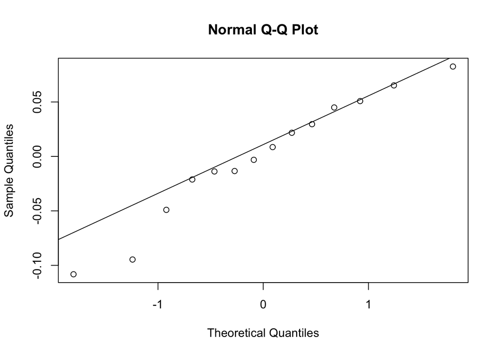

```r
#BMR 0wk
# use lm instead of lmer b/c we do not have repeated measures of bird ID

model_bmr_0wk<- lm(bird_meta_0wk$BMR~bird_meta_0wk$Treatment+bird_meta_0wk$Mass.BMR)

qqnorm(resid(model_bmr_0wk))
qqline(resid(model_bmr_0wk))
```

```r
anova(model_bmr_0wk) # no significant difference between treatment groups at week 0
```

|  | Df | Sum Sq | Mean Sq | F value | Pr(>F) |
| --- | --- | --- | --- | --- | --- |
| bird_meta_0wk$Treatment | 1 | 0.0007124353 | 0.0007124353 | 0.191232 | 0.6703546 |
| bird_meta_0wk$Mass.BMR | 1 | 0.0079113264 | 0.0079113264 | 2.123560 | 0.1729972 |
| Residuals | 11 | 0.0409805188 | 0.0037255017 | NA | NA |

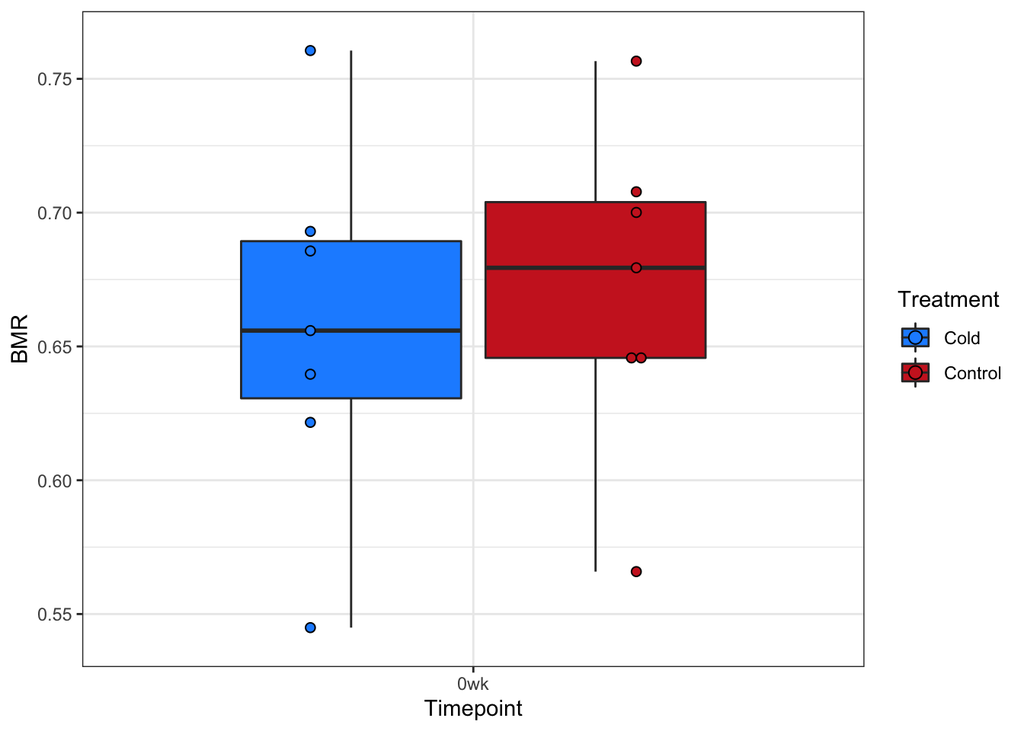

```r
ggplot(bird_meta_0wk, aes(x=Timepoint, y=BMR, fill=Treatment)) +
  geom_boxplot(outlier.shape = NA) + scale_fill_manual(values=c("#1E90FF", "#CD2626")) +  geom_dotplot(binaxis='y', stackdir='center',
  position=position_dodge(1), dotsize = 0.5) + theme_bw()
```

We do not see a significant difference between treatment groups prior to the acclimation start. Now let’s check for a **treatment effect on BMR across the 6-week acclimation**.

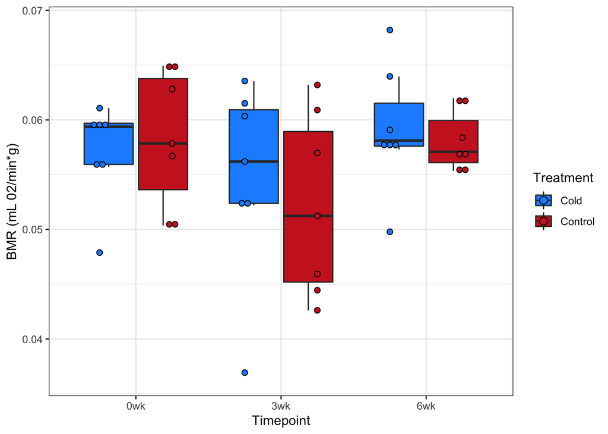

```r
#BMR 0-6wk

model1_bmr_all<- lmer(bird_meta$BMR~bird_meta$Mass.BMR+bird_meta$Treatment*bird_meta$Timepoint+(1|bird_meta$ID))

# plot
ggplot(bird_meta, aes(x=Timepoint, y=BMR.perGram, fill=Treatment)) + ylab("BMR (mL 02/min*g)") +
  geom_boxplot(outlier.shape = NA) + scale_fill_manual(values=c("#1E90FF", "#CD2626")) +  geom_dotplot(binaxis='y', stackdir='center',
  position=position_dodge(1), dotsize = 0.5) + theme_bw()
```

```r
pdf(file=paste("Figure_SX_box_plot_BMR_perGram_",run_date,".pdf",sep=""),height=6,width=8)
ggplot(bird_meta, aes(x=Timepoint, y=BMR.perGram, fill=Treatment)) + ylab("BMR (mL 02/min*g)") +
  geom_boxplot(outlier.shape = NA) + scale_fill_manual(values=c("#1E90FF", "#CD2626")) +  geom_dotplot(binaxis='y', stackdir='center',
  position=position_dodge(1), dotsize = 0.5) + theme_bw()
dev.off()
```

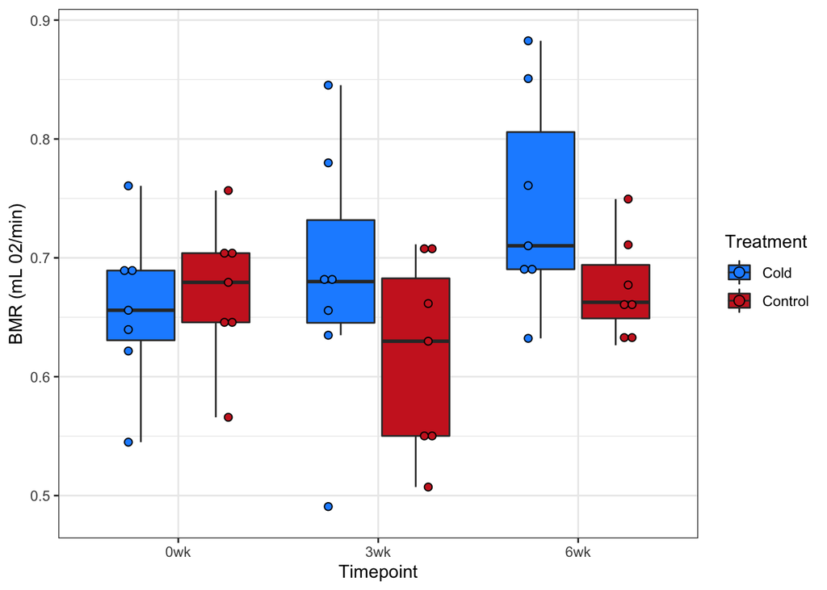

```r
ggplot(bird_meta, aes(x=Timepoint, y=BMR, fill=Treatment)) + ylab("BMR (mL 02/min)") +
  geom_boxplot(outlier.shape = NA) + scale_fill_manual(values=c("#1E90FF", "#CD2626")) +  geom_dotplot(binaxis='y', stackdir='center',
  position=position_dodge(1), dotsize = 0.5) + theme_bw()
```

```r
pdf(file=paste("Figure_1A_box_plot_BMR_",run_date,".pdf",sep=""),height=6,width=8)
ggplot(bird_meta, aes(x=Timepoint, y=BMR, fill=Treatment)) + ylab("BMR (mL 02/min)") +
  geom_boxplot(outlier.shape = NA) + scale_fill_manual(values=c("#1E90FF", "#CD2626")) +  geom_dotplot(binaxis='y', stackdir='center',
  position=position_dodge(1), dotsize = 0.5) + theme_bw()
dev.off()
```

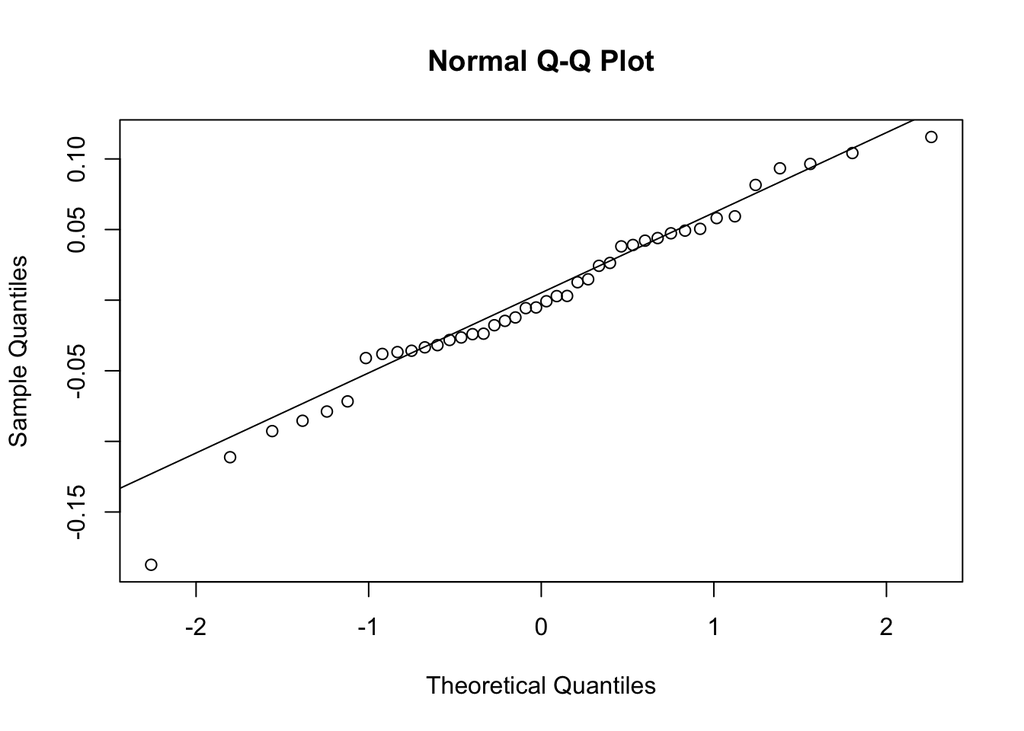

```r
#Given that "model1_bmr" is the best model for BMR, we can check the residuals.

qqnorm(resid(model1_bmr_all))
qqline(resid(model1_bmr_all))
```

```r
anova(model1_bmr_all)
```

|  | Sum Sq | Mean Sq | NumDF | DenDF | F value | Pr(>F) |
| --- | --- | --- | --- | --- | --- | --- |
| bird_meta$Mass.BMR | 0.007600120 | 0.007600120 | 1 | 13.92351 | 1.4964110 | 0.24152480 |
| bird_meta$Treatment | 0.005272666 | 0.005272666 | 1 | 10.74550 | 1.0381513 | 0.33064403 |
| bird_meta$Timepoint | 0.027642985 | 0.013821492 | 2 | 26.40812 | 2.7213561 | 0.08421899 |
| bird_meta$Treatment:bird_meta$Timepoint | 0.008802226 | 0.004401113 | 2 | 25.21309 | 0.8665487 | 0.43254697 |

We see a not-quite-significant effect of timepoint on BMR, but otherwise no significance. Is there a significant effect of treatment on BMR of birds at week 6? Once we account for mass it is not clear.

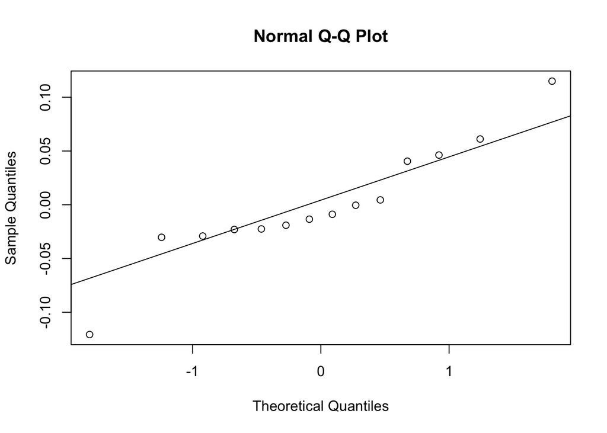

```r
#BMR 6wk

model_bmr_6wk<- lm(bird_meta_6wk$BMR~bird_meta_6wk$Treatment+bird_meta_6wk$Mass.BMR)

qqnorm(resid(model_bmr_6wk))
qqline(resid(model_bmr_6wk))
```

```r
anova(model_bmr_6wk) # significant effect of treatment and mass
```

|  | Df | Sum Sq | Mean Sq | F value | Pr(>F) |
| --- | --- | --- | --- | --- | --- |
| bird_meta_6wk$Treatment | 1 | 0.01733460 | 0.017334601 | 4.923181 | 0.04846496 |
| bird_meta_6wk$Mass.BMR | 1 | 0.02242838 | 0.022428378 | 6.369859 | 0.02828077 |
| Residuals | 11 | 0.03873118 | 0.003521017 | NA | NA |

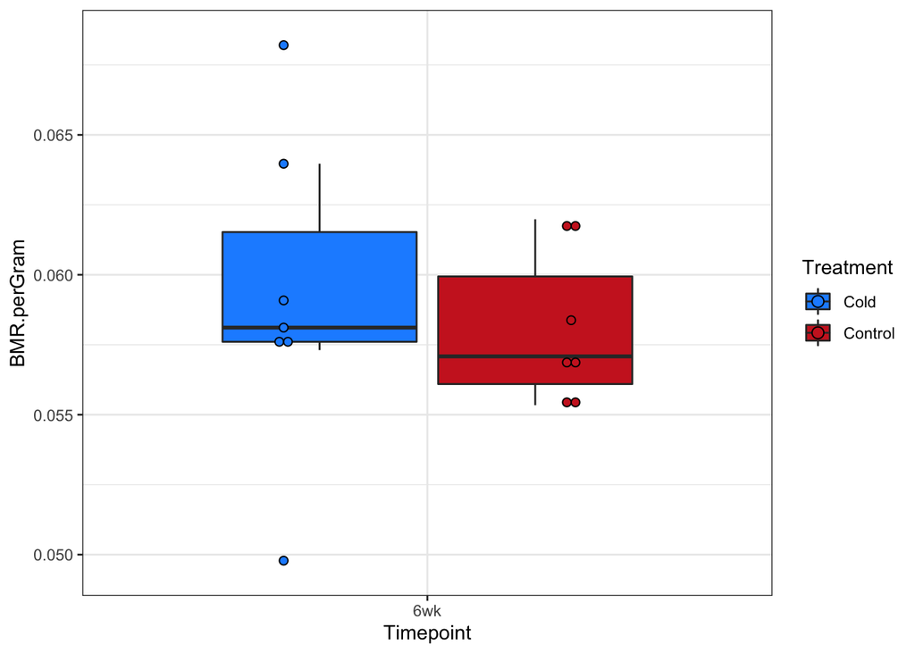

```r
# will plot BMRperGram
ggplot(bird_meta_6wk, aes(x=Timepoint, y=BMR.perGram, fill=Treatment)) +
  geom_boxplot(outlier.shape = NA) + scale_fill_manual(values=c("#1E90FF", "#CD2626")) +  geom_dotplot(binaxis='y', stackdir='center',
  position=position_dodge(1), dotsize = 0.5) + theme_bw()
```

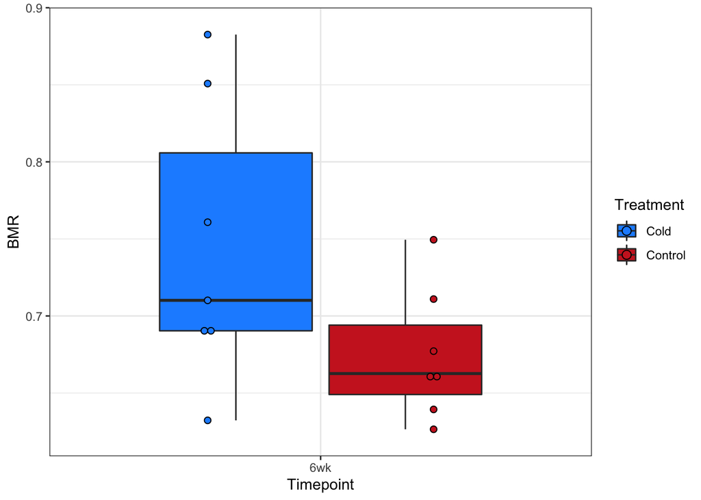

```r
ggplot(bird_meta_6wk, aes(x=Timepoint, y=BMR, fill=Treatment)) +
  geom_boxplot(outlier.shape = NA) + scale_fill_manual(values=c("#1E90FF", "#CD2626")) +  geom_dotplot(binaxis='y', stackdir='center',
  position=position_dodge(1), dotsize = 0.5) + theme_bw()
```

At week 6, there is a significant effect of treatment and mass on measured BMR.

Let’s also check model fit for BMR ~ Mass and BMR ~ Mass + Treatment*Timepoint

```r
#AICc(lmer(bird_meta$BMR ~ bird_meta$Mass.BMR + (1|bird_meta$ID)))
#AICc(lmer(bird_meta$BMR ~ bird_meta$Mass.BMR + bird_meta$Sex + (1|bird_meta$ID)))
#AICc(lmer(bird_meta$BMR~bird_meta$Mass.BMR+bird_meta$Treatment*bird_meta$Timepoint+(1|bird_meta$ID)))

#AICc(lmer(bird_meta_qmr$BMR ~ bird_meta_qmr$lean_mean + (1|bird_meta_qmr$ID)))
#AICc(lmer(bird_meta_qmr$BMR ~ bird_meta_qmr$lean_mean + bird_meta_qmr$Sex + (1|bird_meta_qmr$ID)))
#AICc(lmer(bird_meta_qmr$BMR~ bird_meta_qmr$lean_mean+bird_meta_qmr$Treatment*bird_meta_qmr$Timepoint+(1|bird_meta_qmr$ID)))

#anova(lmer(bird_meta_qmr$BMR ~ bird_meta_qmr$lean_mean + (1|bird_meta_qmr$ID)))
#anova(lmer(bird_meta_qmr$BMR ~ bird_meta_qmr$lean_mean + bird_meta_qmr$Sex + (1|bird_meta_qmr$ID)))
#anova(lmer(bird_meta_qmr$BMR~ bird_meta_qmr$lean_mean+bird_meta_qmr$Treatment*bird_meta_qmr$Timepoint+(1|bird_meta_qmr$ID)))
```

# SMR

Next, we will test whether there was a **significant difference in SMR of treatment groups prior to acclimation**. We would expect no difference.

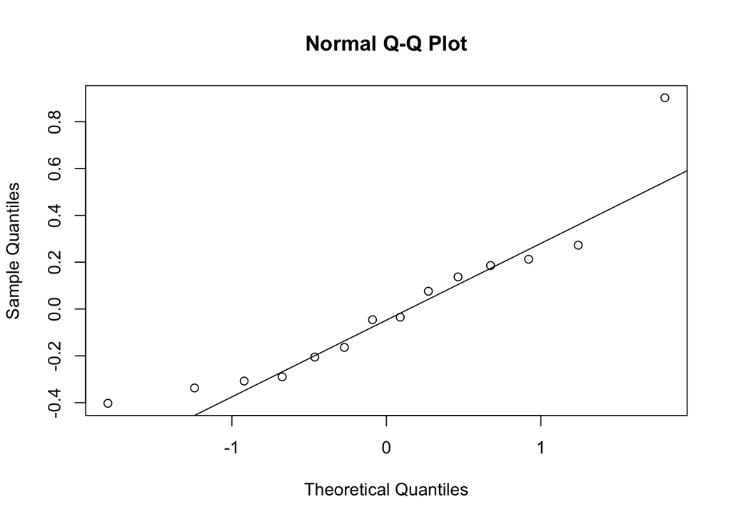

```r
#VO2MAX 0wk

model_smr_0wk<- lm(bird_meta_0wk$VO2max~bird_meta_0wk$Treatment+bird_meta_0wk$Mass.SMR)

qqnorm(resid(model_smr_0wk))
qqline(resid(model_smr_0wk))
```

```r
anova(model_smr_0wk) # no significant difference between treatment groups at week 0
```

|  | Df | Sum Sq | Mean Sq | F value | Pr(>F) |
| --- | --- | --- | --- | --- | --- |
| bird_meta_0wk$Treatment | 1 | 0.006649209 | 0.006649209 | 0.04815245 | 0.8303287 |
| bird_meta_0wk$Mass.SMR | 1 | 0.036259081 | 0.036259081 | 0.26258216 | 0.6184838 |
| Residuals | 11 | 1.518952761 | 0.138086615 | NA | NA |

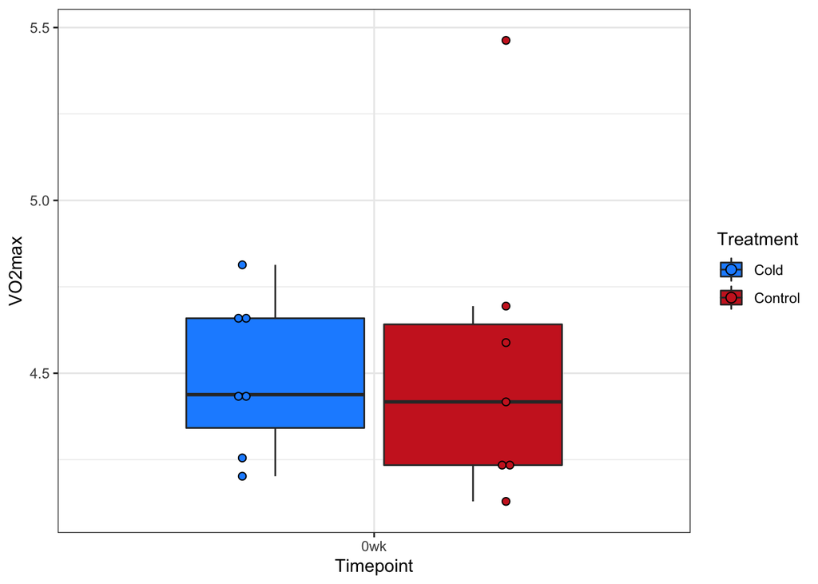

```r
ggplot(bird_meta_0wk, aes(x=Timepoint, y=VO2max, fill=Treatment)) +
  geom_boxplot(outlier.shape = NA) + scale_fill_manual(values=c("#1E90FF", "#CD2626")) +  geom_dotplot(binaxis='y', stackdir='center',
  position=position_dodge(1), dotsize = 0.5) + theme_bw()
```

We do not detect a significant effect of treatment on SMR at week 0. Great! Now, let’s test for an **effect of treatmentxtimepoint on SMR**.

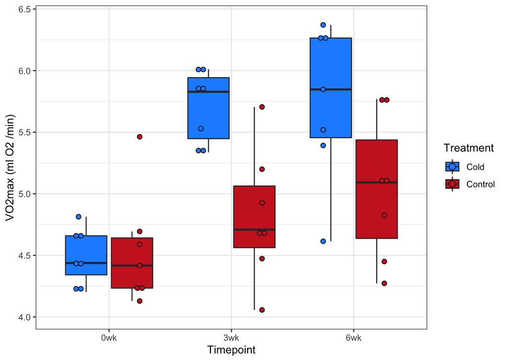

```r
#VO2MAX 0-6wk

model1_smr_all<- lmer(bird_meta$VO2max~bird_meta$Mass.SMR+bird_meta$Treatment*bird_meta$Timepoint+(1|bird_meta$ID))

# plot
ggplot(bird_meta, aes(x=Timepoint, y=VO2max, fill=Treatment)) +ylab("VO2max (ml O2 /min)")+
  geom_boxplot(outlier.shape = NA) + scale_fill_manual(values=c("#1E90FF", "#CD2626")) +  geom_dotplot(binaxis='y', stackdir='center',
  position=position_dodge(1), dotsize = 0.5) + theme_bw()
```

```r
pdf(file=paste("Figure_1B_box_plot_VO2max_",run_date,".pdf",sep=""),height=6,width=8)
ggplot(bird_meta, aes(x=Timepoint, y=VO2max, fill=Treatment)) + ylab("VO2max (ml O2 /min)") +
  geom_boxplot(outlier.shape = NA) + scale_fill_manual(values=c("#1E90FF", "#CD2626")) +  geom_dotplot(binaxis='y', stackdir='center',
  position=position_dodge(1), dotsize = 0.5) + theme_bw()
dev.off()
```

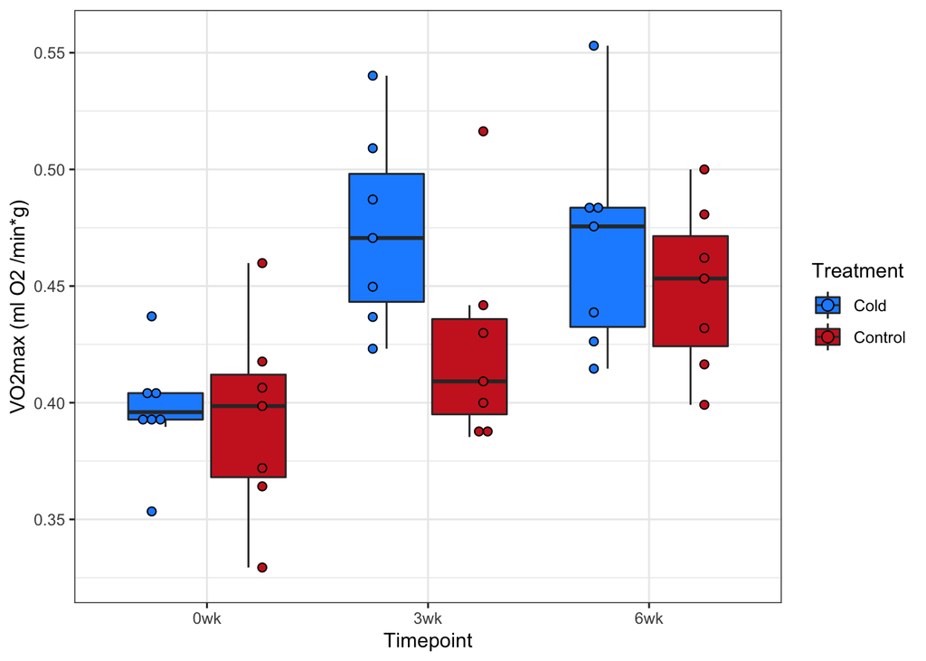

```r
ggplot(bird_meta, aes(x=Timepoint, y=VO2max.perGram, fill=Treatment)) + ylab("VO2max (ml O2 /min*g)") +
  geom_boxplot(outlier.shape = NA) + scale_fill_manual(values=c("#1E90FF", "#CD2626")) +  geom_dotplot(binaxis='y', stackdir='center',
  position=position_dodge(1), dotsize = 0.5) + theme_bw()
```

```r
pdf(file=paste("Figure_SX_box_plot_VO2max_perGram_",run_date,".pdf",sep=""),height=6,width=8)
ggplot(bird_meta, aes(x=Timepoint, y=VO2max.perGram, fill=Treatment)) + ylab("VO2max (ml O2 /min*g)") +
  geom_boxplot(outlier.shape = NA) + scale_fill_manual(values=c("#1E90FF", "#CD2626")) +  geom_dotplot(binaxis='y', stackdir='center',
  position=position_dodge(1), dotsize = 0.5) + theme_bw()
dev.off()
```

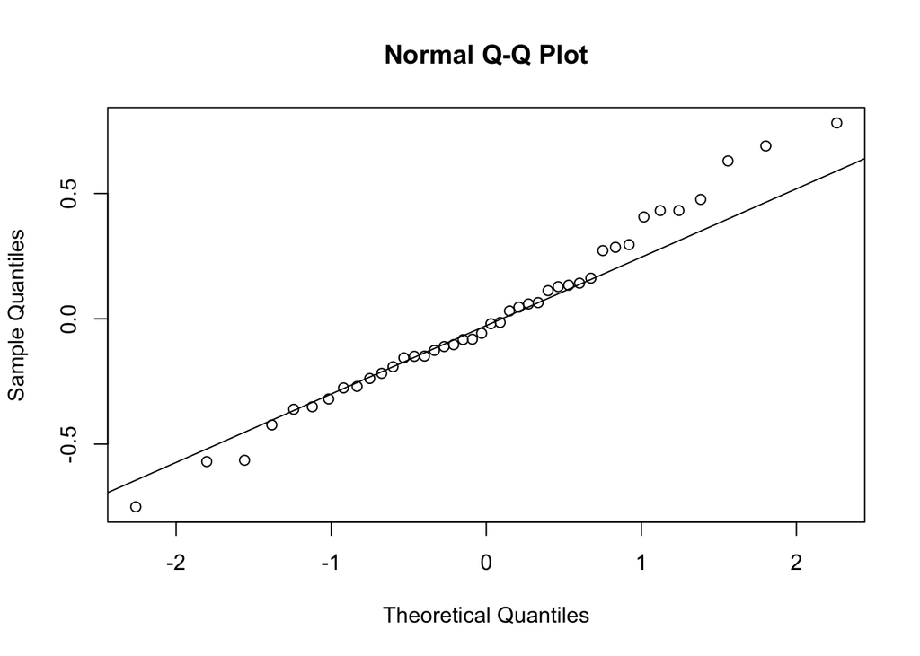

```r
# Given that "model1_smr_all" is the best model for VO2max, we can check the residuals and determine model significance.

qqnorm(resid(model1_smr_all))
qqline(resid(model1_smr_all))
```

```r
anova(model1_smr_all) # sig effect of treatment and timepoint, marginally sig. effect of mass
```

|  | Sum Sq | Mean Sq | NumDF | DenDF | F value | Pr(>F) |
| --- | --- | --- | --- | --- | --- | --- |
| bird_meta$Mass.SMR | 0.6440596 | 0.6440596 | 1 | 14.63633 | 4.051922 | 6.289360e-02 |
| bird_meta$Treatment | 0.7946381 | 0.7946381 | 1 | 11.58305 | 4.999244 | 4.588324e-02 |
| bird_meta$Timepoint | 5.0174568 | 2.5087284 | 2 | 25.18084 | 15.782966 | 3.607501e-05 |
| bird_meta$Treatment:bird_meta$Timepoint | 0.7488811 | 0.3744405 | 2 | 27.84287 | 2.355688 | 1.134548e-01 |

```r
pairs(emmeans(model1_smr_all, ~Treatment*Timepoint), adjust="BH")
```

```
##  contrast                  estimate    SE   df t.ratio p.value
##  Cold 0wk - Control 0wk     0.01778 0.243 30.9   0.073  0.9859
##  Cold 0wk - Cold 3wk       -1.03488 0.232 30.0  -4.459  0.0010
##  Cold 0wk - Control 3wk    -0.31631 0.241 31.2  -1.311  0.2492
##  Cold 0wk - Cold 6wk       -1.03106 0.243 32.6  -4.242  0.0010
##  Cold 0wk - Control 6wk    -0.57500 0.242 31.1  -2.380  0.0443
##  Control 0wk - Cold 3wk    -1.05267 0.249 30.2  -4.233  0.0010
##  Control 0wk - Control 3wk -0.33409 0.215 24.4  -1.555  0.1812
##  Control 0wk - Cold 6wk    -1.04884 0.256 29.3  -4.098  0.0011
##  Control 0wk - Control 6wk -0.59279 0.218 25.5  -2.720  0.0259
##  Cold 3wk - Control 3wk     0.71858 0.257 29.2   2.799  0.0259
##  Cold 3wk - Cold 6wk        0.00382 0.215 24.3   0.018  0.9859
##  Cold 3wk - Control 6wk     0.45988 0.264 28.4   1.745  0.1530
##  Control 3wk - Cold 6wk    -0.71475 0.266 28.1  -2.684  0.0259
##  Control 3wk - Control 6wk -0.25870 0.214 24.1  -1.209  0.2749
##  Cold 6wk - Control 6wk     0.45606 0.275 27.2   1.661  0.1624
##
## Degrees-of-freedom method: kenward-roger
## P value adjustment: BH method for 15 tests
```

Yes, we find a significant effect of treatment and timepoint on SMR. It seems as if cold treatment birds increase their SMR from week 0 to week 3 and maintain it. Is there a significant **difference in SMR between treatment groups at week 6**?

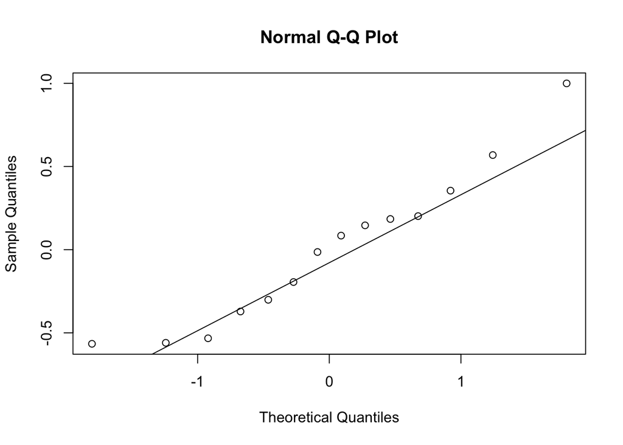

```r
#VO2MAX 6wk

model_smr_6wk<- lm(bird_meta_6wk$VO2max~bird_meta_6wk$Treatment+bird_meta_6wk$Mass.SMR)

qqnorm(resid(model_smr_6wk))
qqline(resid(model_smr_6wk))
```

```r
anova(model_smr_6wk) # significant effect of treatment and mass
```

|  | Df | Sum Sq | Mean Sq | F value | Pr(>F) |
| --- | --- | --- | --- | --- | --- |
| bird_meta_6wk$Treatment | 1 | 1.777620 | 1.7776200 | 7.148246 | 0.02165354 |
| bird_meta_6wk$Mass.SMR | 1 | 1.697454 | 1.6974539 | 6.825879 | 0.02414362 |
| Residuals | 11 | 2.735471 | 0.2486792 | NA | NA |

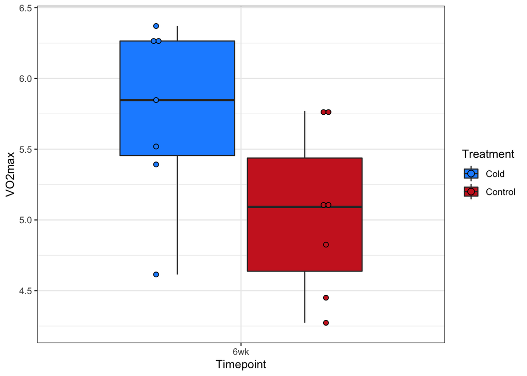

```r
ggplot(bird_meta_6wk, aes(x=Timepoint, y=VO2max, fill=Treatment)) +
  geom_boxplot(outlier.shape = NA) + scale_fill_manual(values=c("#1E90FF", "#CD2626")) +  geom_dotplot(binaxis='y', stackdir='center',
  position=position_dodge(1), dotsize = 0.5) + theme_bw()
```

Yes, there is a significant effect of treatment and mass on SMR at week 6. How about at week 3?

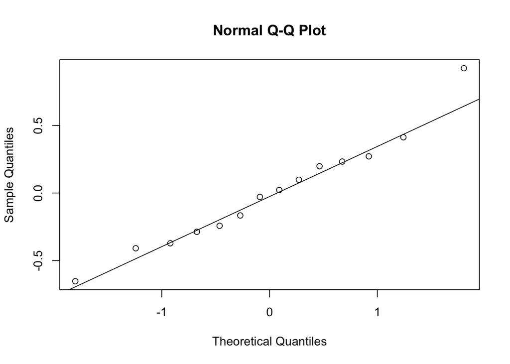

```r
#VO2MAX 3wk

model_smr_3wk<- lm(bird_meta_3wk$VO2max~bird_meta_3wk$Treatment+bird_meta_3wk$Mass.SMR)

qqnorm(resid(model_smr_3wk))
qqline(resid(model_smr_3wk))
```

```r
anova(model_smr_3wk) # significant effect of treatment
```

|  | Df | Sum Sq | Mean Sq | F value | Pr(>F) |
| --- | --- | --- | --- | --- | --- |
| bird_meta_3wk$Treatment | 1 | 2.7757634 | 2.7757634 | 14.5411305 | 0.002876373 |
| bird_meta_3wk$Mass.SMR | 1 | 0.0950821 | 0.0950821 | 0.4980977 | 0.495012621 |
| Residuals | 11 | 2.0997953 | 0.1908905 | NA | NA |

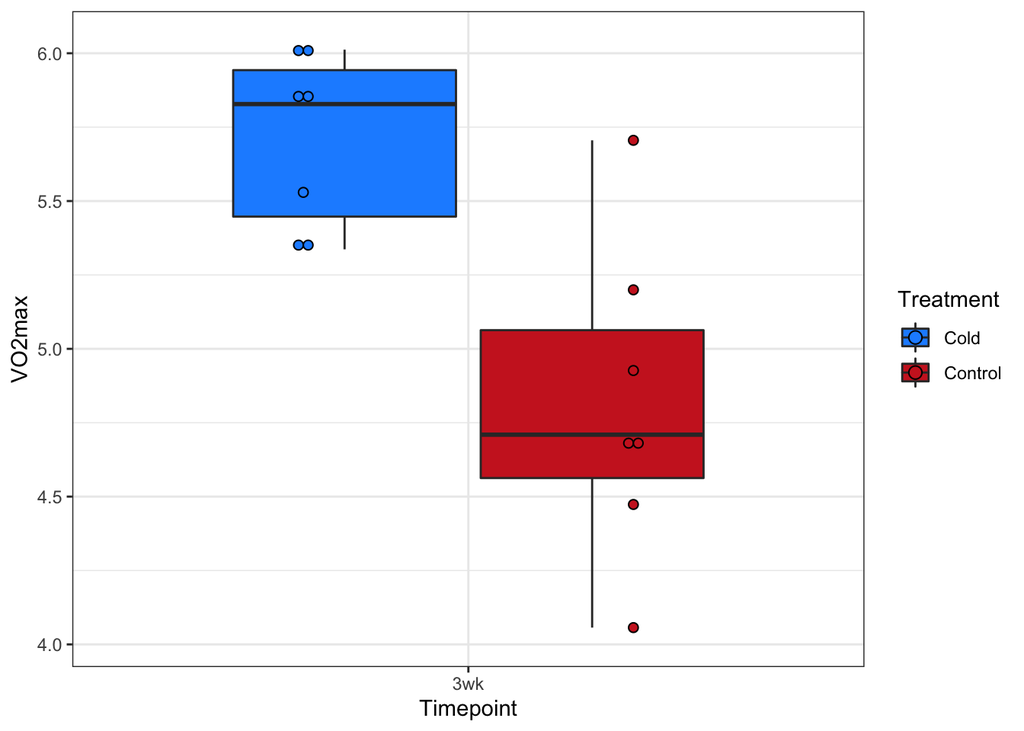

```r
ggplot(bird_meta_3wk, aes(x=Timepoint, y=VO2max, fill=Treatment)) +
  geom_boxplot(outlier.shape = NA) + scale_fill_manual(values=c("#1E90FF", "#CD2626")) +  geom_dotplot(binaxis='y', stackdir='center',
  position=position_dodge(1), dotsize = 0.5) + theme_bw()
```

Yes, there is a significant effect of treatment on SMR at week 3.

Let’s test for which SMR model is the best fit.

```r
#AICc(lmer(bird_meta$VO2max ~ bird_meta$Mass.SMR + (1|bird_meta$ID)))
#AICc(lmer(bird_meta$VO2max ~ bird_meta$Mass.SMR + bird_meta$Sex + (1|bird_meta$ID)))
#AICc(model1_smr_all) # lmer(bird_meta$VO2max~bird_meta$Mass.SMR+bird_meta$Treatment*bird_meta$Timepoint+(1|bird_meta$ID))

#AICc(lmer(bird_meta_qmr$VO2max ~ bird_meta_qmr$lean_mean + (1|bird_meta_qmr$ID)))
#AICc(lmer(bird_meta_qmr$VO2max ~ bird_meta_qmr$lean_mean + bird_meta_qmr$Sex + (1|bird_meta_qmr$ID)))
#AICc(lmer(bird_meta_qmr$VO2max~bird_meta_qmr$lean_mean+bird_meta_qmr$Treatment*bird_meta_qmr$Timepoint+(1|bird_meta_qmr$ID))) #
```

We will also calculate the mean loss of body temperature during SMR trials, and whether there is a difference between treatment groups. We also assess mean time in trial for different groups.

```r
mean(bird_meta$Diff.Tb,na.rm=TRUE)
```

```
## [1] -7.967647
```

```r
temp_diff_control <- bird_meta[bird_meta$Treatment=="Control",c("ID","Treatment","Timepoint","Diff.Tb")]
mean(temp_diff_control$Diff.Tb,na.rm=TRUE) # -8.322222
```

```
## [1] -8.322222
```

```r
temp_diff_cold <- bird_meta[bird_meta$Treatment=="Cold",c("ID","Treatment","Timepoint","Diff.Tb")]
mean(temp_diff_cold$Diff.Tb,na.rm=TRUE) # -7.56875
```

```
## [1] -7.56875
```

```r
temp_diff_model <- lm(bird_meta$Diff.Tb~bird_meta$Treatment)

anova(temp_diff_model)
```

|  | Df | Sum Sq | Mean Sq | F value | Pr(>F) |
| --- | --- | --- | --- | --- | --- |
| bird_meta$Treatment | 1 | 4.808926 | 4.808926 | 0.2650799 | 0.6101898 |
| Residuals | 32 | 580.525486 | 18.141421 | NA | NA |

```r
# time in trials

bird_meta$VO2max.trial.duration <- bird_meta$EndVo2max - bird_meta$Animal.in.VO2max.trial
mean(bird_meta$VO2max.trial.duration,na.rm=TRUE)/60 # 13.6083 min
```

```
## [1] 13.60833
```

```r
hypo <- subset(bird_meta,bird_meta$Timepoint!="0wk")

mean(hypo$VO2max.trial.duration)/60 # 12.17143 min
```

```
## [1] 12.17143
```

# Conductance

Next, let’s process the conductance data to calculate power.

```r
shift <- function(x, n){
  c(x[-(seq(n))], rep(NA, n))
}

Average_Power <- setNames(data.frame(matrix(ncol = 2, nrow = 14)), c("Sample", "Avg.Pwr"))
#Average_Power
#str(Average_Power)

samples <- c("K1","K3","M1","M2","M4","M5","M6","M7","M8","M9","M10","M11","M12","M14")
for (i in c(1:14)){
  file_open <- read.csv(paste("~/Dropbox/chickadee_data/data_files/raw_thermal_conductance_files/",samples[i],".csv",sep=""))
  colnames(file_open) <- c("Time","Voltage.V","Current.mA")
  file_open$Current.mA <- shift(file_open$Current.mA, 1)
  last_row <- dim(file_open)[1]
  #print(last_row)
  file_open <- file_open[-c(last_row),]
  file_open$Power <- file_open$Voltage.V*file_open$Current.mA
  write.csv(file_open, file=paste(samples[i],"_wPower.csv",sep=""),quote=FALSE,row.names=FALSE)
  avg <- mean(file_open[1:1200,4])
  Average_Power[i,1]<-samples[i]
 Average_Power[i,2] <- avg
}

write.csv(Average_Power, file=paste("~/Dropbox/chickadee_data/data_files/Average_Power",run_date,".csv",sep=""),quote=FALSE,row.names=FALSE)
```

Let’s now test for an **effect of room temperature or sampling date on conductance**, so we know whether we should include them in our models.

```r
# Import room temperature data to add to models
conductance_data <- read.csv("~/Dropbox/chickadee_data/data_files/Conductance_Trial_Data_simp_26Apr2022.csv")

bird_meta_6wk_wCond <- merge(bird_meta_6wk,Average_Power,by.x="ID",by.y="Sample")
bird_meta_6wk_wCond_final <- merge(bird_meta_6wk_wCond,conductance_data,by.x="ID",by.y="Sample_ID")

# One heart measure for bird M8 was noted as perhaps not being tared properly before weighing, and mass is ~2x the size of all the other hearts. Will change to NA.

bird_meta_6wk_wCond_final[13,"Mass.Heart"] <- NA
bird_meta_6wk_wCond_final[13,"Mass.Heart.perGram"] <- NA

# Assess model fit

# We will be using the "Avg.Pwr" column from our lastwk_data dataframe
# IS there a sig effect of room temp or date on power?

anova(lm(bird_meta_6wk_wCond_final$Avg.Pwr~bird_meta_6wk_wCond_final$Room_Temp)) # no significance (0.872)
```

|  | Df | Sum Sq | Mean Sq | F value | Pr(>F) |
| --- | --- | --- | --- | --- | --- |
| bird_meta_6wk_wCond_final$Room_Temp | 1 | 112.3935 | 112.3935 | 0.02708358 | 0.8720213 |
| Residuals | 12 | 49798.5300 | 4149.8775 | NA | NA |

```r
anova(lm(bird_meta_6wk_wCond_final$Avg.Pwr~bird_meta_6wk_wCond_final$Date)) # not significant (0.08)
```

|  | Df | Sum Sq | Mean Sq | F value | Pr(>F) |
| --- | --- | --- | --- | --- | --- |
| bird_meta_6wk_wCond_final$Date | 6 | 36090.67 | 6015.111 | 3.046672 | 0.08544724 |
| Residuals | 7 | 13820.26 | 1974.322 | NA | NA |

```r
# b/c of marginal significance of date, test model fit including date or not.

model1_power<- lm(bird_meta_6wk_wCond_final$Avg.Pwr~bird_meta_6wk_wCond_final$Treatment)

model2_power<- lm(bird_meta_6wk_wCond_final$Avg.Pwr~bird_meta_6wk_wCond_final$Treatment + bird_meta_6wk_wCond_final$Date)

print(AICc(model1_power)) # lower AICc
```

```
## [1] 162.3301
```

```r
print(AICc(model2_power))
```

```
## [1] 193.3326
```

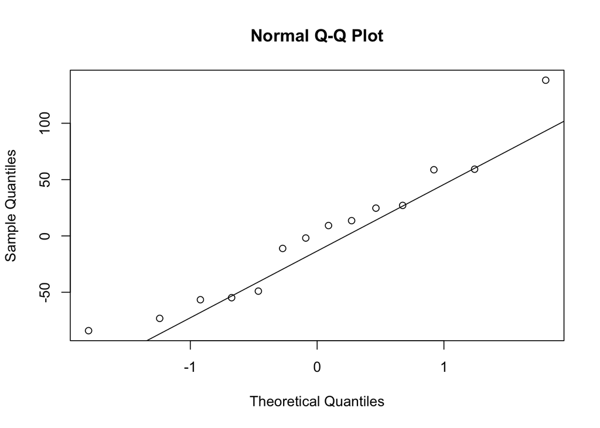

```r
# Assess significance for model1_power, the best model

qqnorm(resid(model1_power))
qqline(resid(model1_power))
```

```r
anova(model1_power) # no effect of treatment on power
```

|  | Df | Sum Sq | Mean Sq | F value | Pr(>F) |
| --- | --- | --- | --- | --- | --- |
| bird_meta_6wk_wCond_final$Treatment | 1 | 1076.835 | 1076.835 | 0.2646106 | 0.6163117 |
| Residuals | 12 | 48834.089 | 4069.507 | NA | NA |

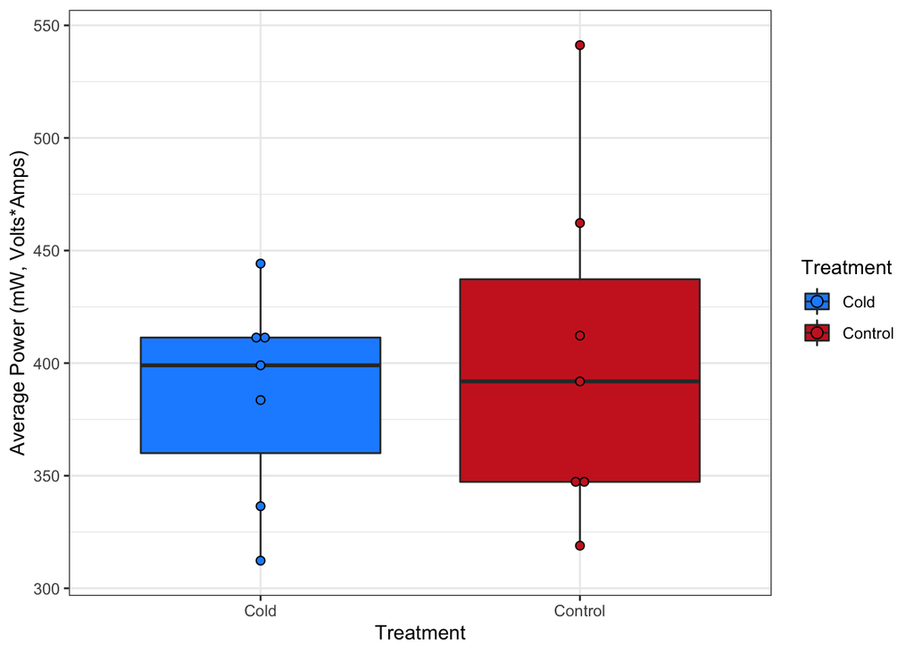

```r
ggplot(bird_meta_6wk_wCond_final, aes(x=Treatment, y=Avg.Pwr, fill=Treatment)) + ylab("Average Power (mW, Volts*Amps)") +
  geom_boxplot(outlier.shape = NA) + scale_fill_manual(values=c("#1E90FF", "#CD2626")) +  geom_dotplot(binaxis='y', stackdir='center',
  position=position_dodge(1), dotsize = 0.5) + theme_bw()
```

```r
pdf(file=paste("Figure_3_box_plot_power_",run_date,".pdf",sep=""),height=6,width=8)
ggplot(bird_meta_6wk_wCond_final, aes(x=Treatment, y=Avg.Pwr, fill=Treatment)) + ylab("Average Power (mW, Volts*Amps)") +
  geom_boxplot(outlier.shape = NA) + scale_fill_manual(values=c("#1E90FF", "#CD2626")) +  geom_dotplot(binaxis='y', stackdir='center',
  position=position_dodge(1), dotsize = 0.5) + theme_bw()
dev.off()
```

# Other phenotypes (Hb, RBC, heart mass)

No significant effect of treatment or room temperature on power measurements. Is there a significant **effect of treatment on hemoglobin**?

```r
# no sig. effect of mass or sex on Hb
anova(lm(bird_meta_6wk_wCond_final$Hb~bird_meta_6wk_wCond_final$Mass.SMR))
```

|  | Df | Sum Sq | Mean Sq | F value | Pr(>F) |
| --- | --- | --- | --- | --- | --- |
| bird_meta_6wk_wCond_final$Mass.SMR | 1 | 0.2337048 | 0.2337048 | 0.06923466 | 0.7977963 |
| Residuals | 10 | 33.7554619 | 3.3755462 | NA | NA |

```r
anova(lm(bird_meta_6wk_wCond_final$Hb~bird_meta_6wk_wCond_final$Sex))
```

|  | Df | Sum Sq | Mean Sq | F value | Pr(>F) |
| --- | --- | --- | --- | --- | --- |
| bird_meta_6wk_wCond_final$Sex | 1 | 2.470417 | 2.470417 | 0.7837927 | 0.3967726 |
| Residuals | 10 | 31.518750 | 3.151875 | NA | NA |

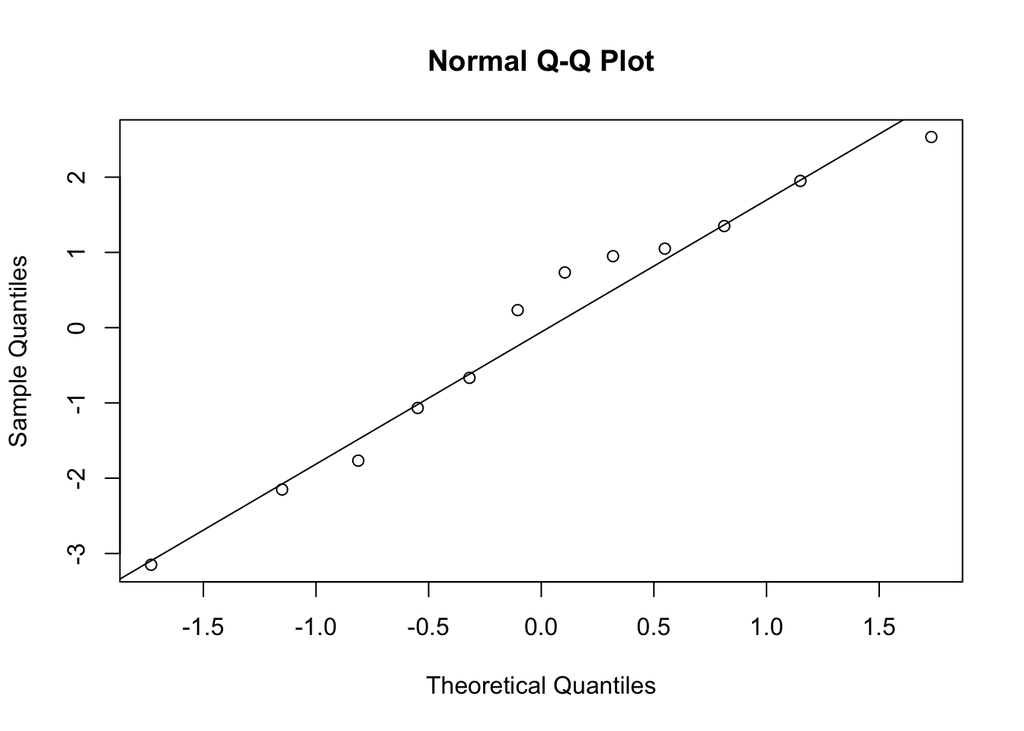

```r
model1_hb<- lm(bird_meta_6wk_wCond_final$Hb~bird_meta_6wk_wCond_final$Treatment)

qqnorm(resid(model1_hb))
qqline(resid(model1_hb))
```

```r
anova(model1_hb)
```

|  | Df | Sum Sq | Mean Sq | F value | Pr(>F) |
| --- | --- | --- | --- | --- | --- |
| bird_meta_6wk_wCond_final$Treatment | 1 | 0.1008333 | 0.1008333 | 0.02975459 | 0.8664894 |
| Residuals | 10 | 33.8883333 | 3.3888333 | NA | NA |

No effect of treatment on Hb. Is there a significant **effect of treatment on RBC**?

```r
# no sig. effect of mass or sex on % RBC
anova(lm(bird_meta_6wk_wCond_final$PercRBC~bird_meta_6wk_wCond_final$Mass.SMR))
```

|  | Df | Sum Sq | Mean Sq | F value | Pr(>F) |
| --- | --- | --- | --- | --- | --- |
| bird_meta_6wk_wCond_final$Mass.SMR | 1 | 0.002121338 | 0.002121338 | 0.6322767 | 0.4526353 |
| Residuals | 7 | 0.023485553 | 0.003355079 | NA | NA |

```r
anova(lm(bird_meta_6wk_wCond_final$PercRBC~bird_meta_6wk_wCond_final$Sex))
```

|  | Df | Sum Sq | Mean Sq | F value | Pr(>F) |
| --- | --- | --- | --- | --- | --- |
| bird_meta_6wk_wCond_final$Sex | 1 | 0.003356851 | 0.003356851 | 1.056086 | 0.3383044 |
| Residuals | 7 | 0.022250041 | 0.003178577 | NA | NA |

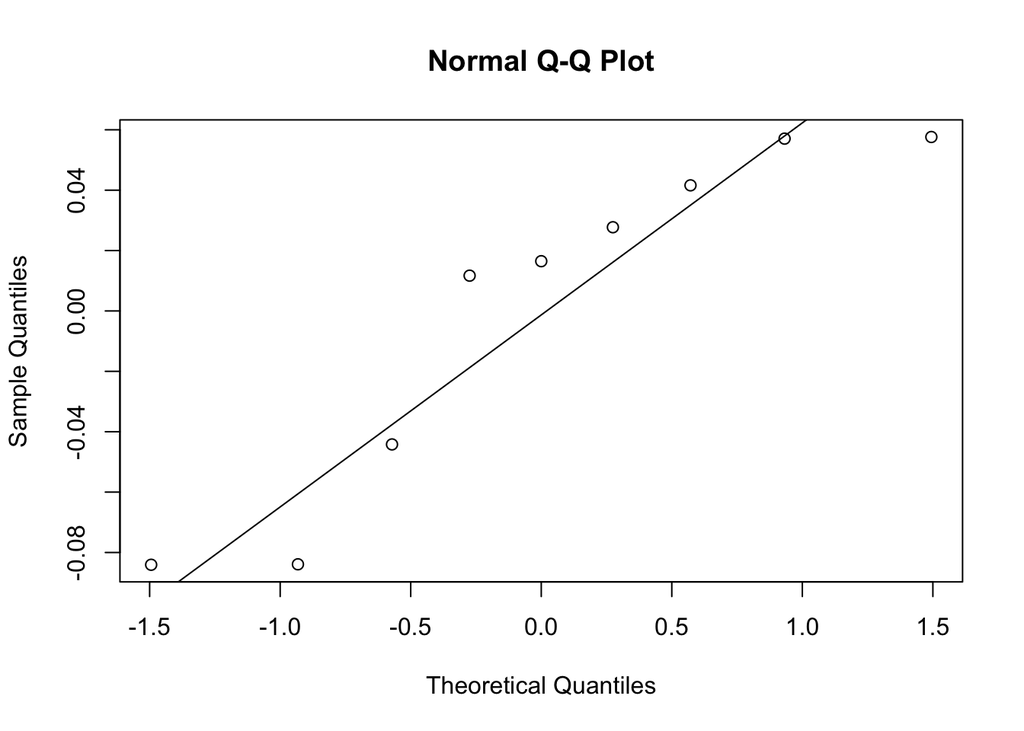

```r
model1_rbc<- lm(bird_meta_6wk_wCond_final$PercRBC~bird_meta_6wk_wCond_final$Treatment)

qqnorm(resid(model1_rbc))
qqline(resid(model1_rbc))
```

```r
anova(model1_rbc)
```

|  | Df | Sum Sq | Mean Sq | F value | Pr(>F) |
| --- | --- | --- | --- | --- | --- |
| bird_meta_6wk_wCond_final$Treatment | 1 | 6.039054e-05 | 6.039054e-05 | 0.01654762 | 0.9012624 |
| Residuals | 7 | 2.554650e-02 | 3.649500e-03 | NA | NA |

No significant effect of treatment on RBC. Is there a significant **effect of treatment on heart mass**?

```r
# no sig. effect of body mass on heart mass, but sig. effect of sex

anova(lm(bird_meta_6wk_wCond_final$Mass.Heart~bird_meta_6wk_wCond_final$Mass.SMR))
```

|  | Df | Sum Sq | Mean Sq | F value | Pr(>F) |
| --- | --- | --- | --- | --- | --- |
| bird_meta_6wk_wCond_final$Mass.SMR | 1 | 0.002031003 | 0.002031003 | 2.464648 | 0.1447334 |
| Residuals | 11 | 0.009064594 | 0.000824054 | NA | NA |

```r
anova(lm(bird_meta_6wk_wCond_final$Mass.Heart~bird_meta_6wk_wCond_final$Sex))
```

|  | Df | Sum Sq | Mean Sq | F value | Pr(>F) |
| --- | --- | --- | --- | --- | --- |
| bird_meta_6wk_wCond_final$Sex | 1 | 0.003524403 | 0.0035244026 | 5.120517 | 0.04486667 |
| Residuals | 11 | 0.007571194 | 0.0006882904 | NA | NA |

```r
model1_heart<- lm(bird_meta_6wk_wCond_final$Mass.Heart~bird_meta_6wk_wCond_final$Treatment+bird_meta_6wk_wCond_final$Sex)
model2_heart<- lm(bird_meta_6wk_wCond_final$Mass.Heart~bird_meta_6wk_wCond_final$Treatment)

AICc(model1_heart)
```

```
## [1] -51.39814
```

```r
AICc(model2_heart)
```

```
## [1] -46.81535
```

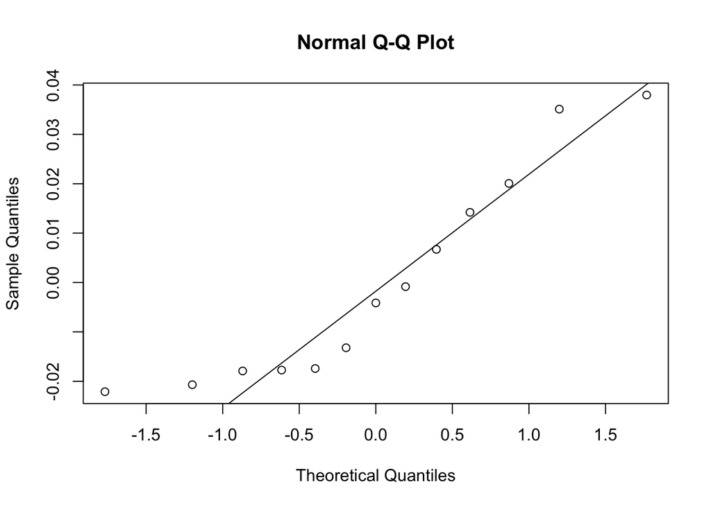

```r
qqnorm(resid(model1_heart))
qqline(resid(model1_heart))
```

```r
anova(model1_heart)
```

|  | Df | Sum Sq | Mean Sq | F value | Pr(>F) |
| --- | --- | --- | --- | --- | --- |
| bird_meta_6wk_wCond_final$Treatment | 1 | 0.0004304598 | 0.0004304598 | 0.8013633 | 0.39172410 |
| bird_meta_6wk_wCond_final$Sex | 1 | 0.0052935440 | 0.0052935440 | 9.8547003 | 0.01052413 |
| Residuals | 10 | 0.0053715931 | 0.0005371593 | NA | NA |

No effect of treatment on heart mass, but effect of sex on heart mass.

# QMR

Now let’s look at the QMR data.

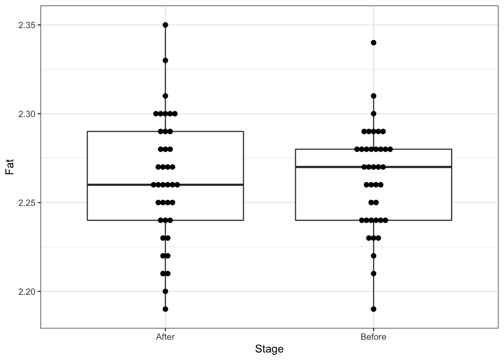

```r
qmr_raw<- read.csv("~/Dropbox/chickadee_data/data_files/qmr_extractedResults_for_R.csv")

# isolate standards
standards<- qmr_raw[qmr_raw$Expected!="Sample",]
# standards<- standards[standards$RecNumber!=c(88:90),]
standards$Expected<- as.numeric(standards$Expected)

standards_2<- standards[standards$Expected==2.0,]
standards_5<- standards[standards$Expected==5.0,]
standards_15<- standards[standards$Expected==15.3,]

# Plot the standards before and after measurements
ggplot(standards_2, aes(x=Stage, y=Fat,)) +
  geom_boxplot(outlier.shape = NA) + scale_fill_manual(values=c("#1E90FF", "#CD2626")) +  geom_dotplot(binaxis='y', stackdir='center',
  position=position_dodge(1), dotsize = 0.5) + theme_bw()
```

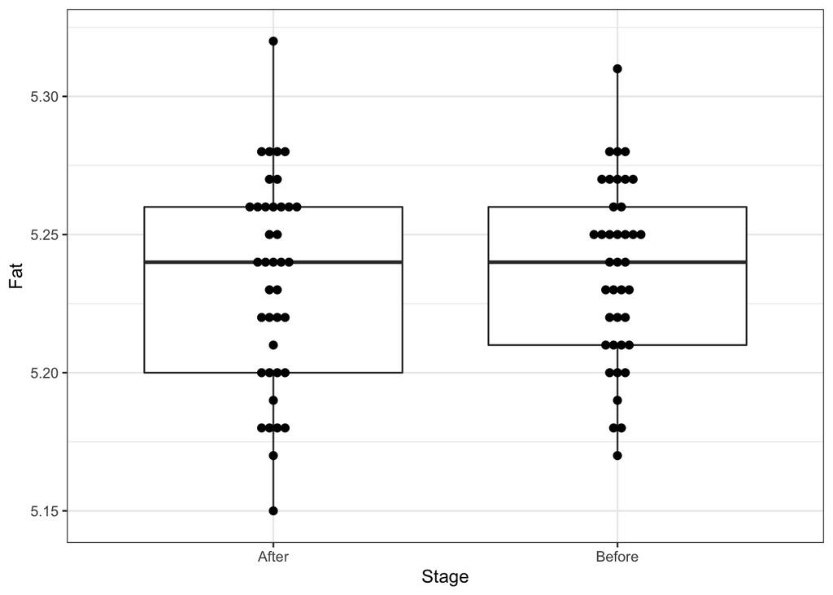

```r
ggplot(standards_5, aes(x=Stage, y=Fat,)) +
  geom_boxplot(outlier.shape = NA) + scale_fill_manual(values=c("#1E90FF", "#CD2626")) +  geom_dotplot(binaxis='y', stackdir='center',
  position=position_dodge(1), dotsize = 0.5) + theme_bw()
```

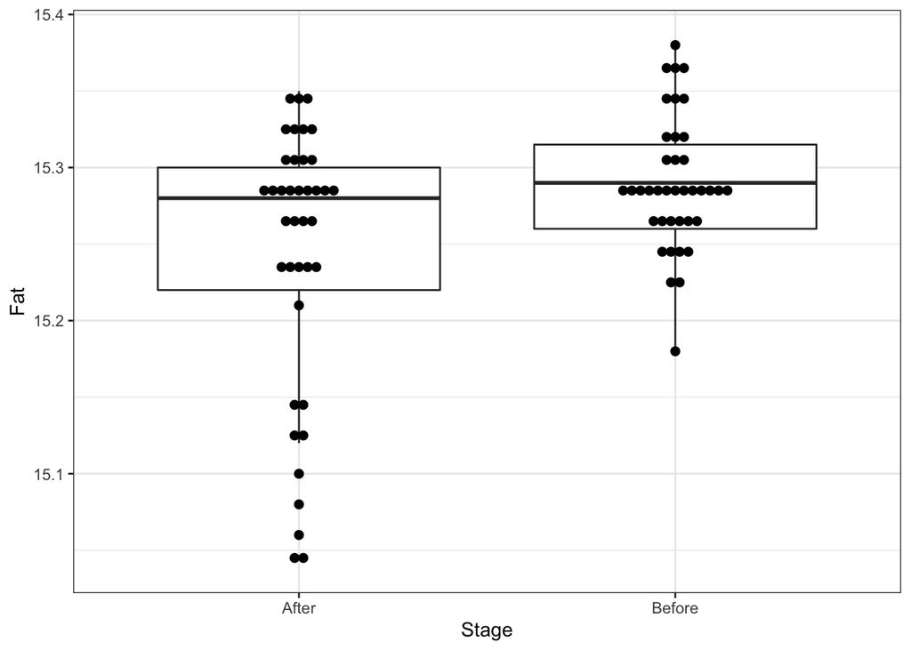

```r
ggplot(standards_15, aes(x=Stage, y=Fat,)) +
  geom_boxplot(outlier.shape = NA) + scale_fill_manual(values=c("#1E90FF", "#CD2626")) +  geom_dotplot(binaxis='y', stackdir='center',
  position=position_dodge(1), dotsize = 0.5) + theme_bw()
```

```r
# Do we need to take into account differences in standard measurements before and after? Short answer, yes.

model1_fat<- lm(Fat~Expected,data=standards)
model2_fat<- lm(Fat~Expected+Date,data=standards)
model3_fat<- lm(Fat~Expected+Date+Stage, data=standards)

AICc(model1_fat)
```

```
## [1] -703.0559
```

```r
AICc(model2_fat)
```

```
## [1] -708.8257
```

```r
AICc(model3_fat) #lowest AICc
```

```
## [1] -713.6253
```

```r
summary(model3_fat)
```

```
##
## Call:
## lm(formula = Fat ~ Expected + Date + Stage, data = standards)
##
## Residuals:
##       Min        1Q    Median        3Q       Max
## -0.189603 -0.025714  0.001694  0.033014  0.121551
##
## Coefficients:
##                 Estimate Std. Error  t value Pr(>|t|)
## (Intercept)    0.3175556  0.0131003   24.240   <2e-16 ***
## Expected       0.9766770  0.0005804 1682.740   <2e-16 ***
## Date11-Sep-20 -0.0294444  0.0168568   -1.747   0.0821 .
## Date15-Sep-20 -0.0311111  0.0168568   -1.846   0.0663 .
## Date16-Sep-20 -0.0283333  0.0168568   -1.681   0.0942 .
## Date2-Oct-20   0.0005556  0.0168568    0.033   0.9737
## Date23-Oct-20  0.0127778  0.0168568    0.758   0.4493
## Date26-Oct-20  0.0188889  0.0168568    1.121   0.2637
## Date27-Oct-20  0.0200000  0.0168568    1.186   0.2367
## Date3-Oct-20  -0.0050000  0.0168568   -0.297   0.7670
## Date30-Oct-20  0.0194444  0.0168568    1.154   0.2500
## Date4-Oct-20   0.0177778  0.0168568    1.055   0.2928
## Date8-Oct-20   0.0138889  0.0168568    0.824   0.4109
## Date9-Oct-20   0.0161111  0.0168568    0.956   0.3402
## StageBefore    0.0171795  0.0066118    2.598   0.0100 *
## ---
## Signif. codes:  0 '***' 0.001 '**' 0.01 '*' 0.05 '.' 0.1 ' ' 1
##
## Residual standard error: 0.05057 on 219 degrees of freedom
## Multiple R-squared:  0.9999, Adjusted R-squared:  0.9999
## F-statistic: 2.023e+05 on 14 and 219 DF,  p-value: < 2.2e-16
```

```r
anova(model3_fat)
```

|  | Df | Sum Sq | Mean Sq | F value | Pr(>F) |
| --- | --- | --- | --- | --- | --- |
| Expected | 1 | 7.241497e+03 | 7.241497e+03 | 2.831613e+06 | 0.000000000 |
| Date | 12 | 8.422906e-02 | 7.019088e-03 | 2.744646e+00 | 0.001728847 |
| Stage | 1 | 1.726538e-02 | 1.726538e-02 | 6.751213e+00 | 0.010004376 |
| Residuals | 219 | 5.600651e-01 | 2.557375e-03 | NA | NA |

The initial analysis of the QMR standards data suggests that there are significant effects of date and stage (before/after) on the measured fat, so we need to account for that.

```r
dates<- unique(as.list(standards$Date))

corrected_qmr <- data.frame()
counter = 1

bird_meta$Label <- paste(bird_meta$ID,bird_meta$Timepoint, sep = "_") # make sure labels line up for meta & qmr

## FOR LOOP ##
for(i in dates) {

  # get qmr data for the day
  qmr_day <- filter(qmr_raw, Date == i)

  qmr_day_standards <- filter(qmr_day, Expected != "Sample")
  qmr_day_standards$Expected <- as.numeric(qmr_day_standards$Expected)

  ## Generate model off of refined df
  model <- lm(Fat~Expected,data=qmr_day_standards)

   # B
  coef_b <- coef(summary(model))["(Intercept)","Estimate"]

  # M
  coef_m <- coef(summary(model))["Expected","Estimate"]

  # For loop to iterate over qmr data to add the day's standard model
  #Figure out how to make the formula include the days standard coefficients
  for(row in 1:nrow(qmr_day)) {
    qmr_day$fat_corrected[row] =  (qmr_day$Fat[row]-coef_b)/coef_m# FORUMLA FOR FAT CORRECTED
  }

  aggregate(fat_corrected ~ Label, data=qmr_day,mean)

  # bind (append) df
  corrected_qmr <- rbind(corrected_qmr, qmr_day)

} # Exit for loop

qmr_means <- aggregate(fat_corrected ~ Label, data=corrected_qmr,mean)
qmr_means$lean_mean <- aggregate(Lean ~ Label, data=corrected_qmr,mean)[,2]
qmr_means$freewater_mean <- aggregate(FreeWater ~ Label, data=corrected_qmr,mean)[,2]
qmr_means$totalwater_mean <- aggregate(TotalWater ~ Label, data=corrected_qmr,mean)[,2]

qmr_means<- head(qmr_means, 42) # remove the standards

for (i in c(1:42)){
  if (qmr_means[i,"fat_corrected"] < 0){ # if values are negative
    qmr_means[i,"fat_corrected"] <- 0 # set values to 0
  }
}

colnames(qmr_means) <- c("Label","fat_corrected_mean", "lean_mean", "freewater_mean", "totalwater_mean")

bird_meta_qmr<- merge(bird_meta, qmr_means, by= "Label", all.x = TRUE)

bird_meta_qmr$perc_lean_mean<- (bird_meta_qmr$lean_mean/bird_meta_qmr$Mass.SMR)

bird_meta_qmr$perc_fat_corrected_mean<- (bird_meta_qmr$fat_corrected_mean/bird_meta_qmr$Mass.SMR)
```

Now that we have the QMR data processed, we can use lean mass in our models for BMR and SMR.

```r
AICc(lmer(bird_meta$BMR ~ bird_meta$Mass.BMR + (1|bird_meta$ID)))
```

```
## [1] -73.16198
```

```r
AICc(lmer(bird_meta$BMR ~ bird_meta$Mass.BMR + bird_meta$Sex + (1|bird_meta$ID)))
```

```
## [1] -66.52534
```

```r
AICc(lmer(bird_meta$BMR~bird_meta$Mass.BMR+bird_meta$Treatment*bird_meta$Timepoint+(1|bird_meta$ID)))
```

```
## [1] -42.13252
```

```r
AICc(lmer(bird_meta_qmr$BMR ~ bird_meta_qmr$lean_mean + (1|bird_meta_qmr$ID)))
```

```
## [1] -76.84943
```

```r
AICc(lmer(bird_meta_qmr$BMR ~ bird_meta_qmr$lean_mean + bird_meta_qmr$Sex + (1|bird_meta_qmr$ID)))
```

```
## [1] -69.74561
```

```r
AICc(lmer(bird_meta_qmr$BMR~ bird_meta_qmr$lean_mean+bird_meta_qmr$Treatment*bird_meta_qmr$Timepoint+(1|bird_meta_qmr$ID)))
```

```
## [1] -44.34394
```

```r
anova(lmer(bird_meta_qmr$BMR ~ bird_meta_qmr$lean_mean + (1|bird_meta_qmr$ID)))
```

|  | Sum Sq | Mean Sq | NumDF | DenDF | F value | Pr(>F) |
| --- | --- | --- | --- | --- | --- | --- |
| bird_meta_qmr$lean_mean | 0.03833813 | 0.03833813 | 1 | 15.61506 | 7.496206 | 0.01483474 |

```r
anova(lmer(bird_meta_qmr$BMR ~ bird_meta_qmr$lean_mean + bird_meta_qmr$Sex + (1|bird_meta_qmr$ID)))
```

|  | Sum Sq | Mean Sq | NumDF | DenDF | F value | Pr(>F) |
| --- | --- | --- | --- | --- | --- | --- |
| bird_meta_qmr$lean_mean | 0.0174576534 | 0.0174576534 | 1 | 20.97868 | 3.400693886 | 0.07933941 |
| bird_meta_qmr$Sex | 0.0000136322 | 0.0000136322 | 1 | 15.36500 | 0.002655508 | 0.95956589 |

```r
anova(lmer(bird_meta_qmr$BMR~ bird_meta_qmr$lean_mean+bird_meta_qmr$Treatment*bird_meta_qmr$Timepoint+(1|bird_meta_qmr$ID)))
```

|  | Sum Sq | Mean Sq | NumDF | DenDF | F value | Pr(>F) |
| --- | --- | --- | --- | --- | --- | --- |
| bird_meta_qmr$lean_mean | 0.015007051 | 0.015007051 | 1 | 11.83929 | 3.1405364 | 0.1020767 |
| bird_meta_qmr$Treatment | 0.004076893 | 0.004076893 | 1 | 11.12307 | 0.8531743 | 0.3752588 |
| bird_meta_qmr$Timepoint | 0.023068481 | 0.011534241 | 2 | 24.73806 | 2.4137788 | 0.1102487 |
| bird_meta_qmr$Treatment:bird_meta_qmr$Timepoint | 0.007681674 | 0.003840837 | 2 | 26.07112 | 0.8037747 | 0.4584207 |

```r
AICc(lmer(bird_meta$VO2max ~ bird_meta$Mass.SMR + (1|bird_meta$ID)))
```

```
## [1] 86.7583
```

```r
AICc(lmer(bird_meta$VO2max ~ bird_meta$Mass.SMR + bird_meta$Sex + (1|bird_meta$ID)))
```

```
## [1] 89.96462
```

```r
AICc(model1_smr_all) # lmer(bird_meta$VO2max~bird_meta$Mass.SMR+bird_meta$Treatment*bird_meta$Timepoint+(1|bird_meta$ID))
```

```
## [1] 80.04172
```

```r
AICc(lmer(bird_meta_qmr$VO2max ~ bird_meta_qmr$lean_mean + (1|bird_meta_qmr$ID)))
```

```
## [1] 89.69097
```

```r
AICc(lmer(bird_meta_qmr$VO2max ~ bird_meta_qmr$lean_mean + bird_meta_qmr$Sex + (1|bird_meta_qmr$ID)))
```

```
## [1] 92.56576
```

```r
AICc(lmer(bird_meta_qmr$VO2max~bird_meta_qmr$lean_mean+bird_meta_qmr$Treatment*bird_meta_qmr$Timepoint+(1|bird_meta_qmr$ID))) #
```

```
## [1] 79.66637
```

Next, we test for significant **effect of treatment on overall fat**. We do not include body mass as a covariate in these models since it is not independent of lean mass.

```r
# unsurprisingly, there is a very large effect of bird mass on fat value.
anova(lmer(bird_meta_qmr$fat_corrected_mean~bird_meta_qmr$Mass.SMR +(1|bird_meta_qmr$ID)))
```

|  | Sum Sq | Mean Sq | NumDF | DenDF | F value | Pr(>F) |
| --- | --- | --- | --- | --- | --- | --- |
| bird_meta_qmr$Mass.SMR | 0.2580044 | 0.2580044 | 1 | 39.79074 | 13.8427 | 0.0006135349 |

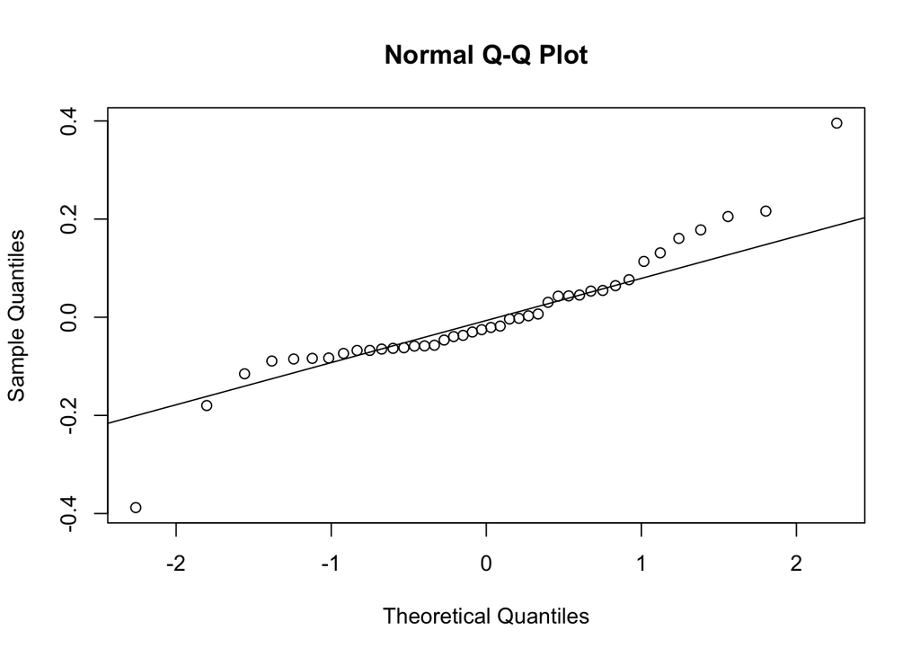

```r
model1_fatC<- lmer(bird_meta_qmr$fat_corrected_mean~bird_meta_qmr$Treatment*bird_meta_qmr$Timepoint+(1|bird_meta_qmr$ID))

qqnorm(resid(model1_fatC))
qqline(resid(model1_fatC))
```

```r
anova(model1_fatC)
```

|  | Sum Sq | Mean Sq | NumDF | DenDF | F value | Pr(>F) |
| --- | --- | --- | --- | --- | --- | --- |
| bird_meta_qmr$Treatment | 0.02942020 | 0.02942020 | 1 | 12 | 1.206275 | 0.2936196 |
| bird_meta_qmr$Timepoint | 0.07486687 | 0.03743343 | 2 | 24 | 1.534830 | 0.2359072 |
| bird_meta_qmr$Treatment:bird_meta_qmr$Timepoint | 0.09381597 | 0.04690798 | 2 | 24 | 1.923302 | 0.1679841 |

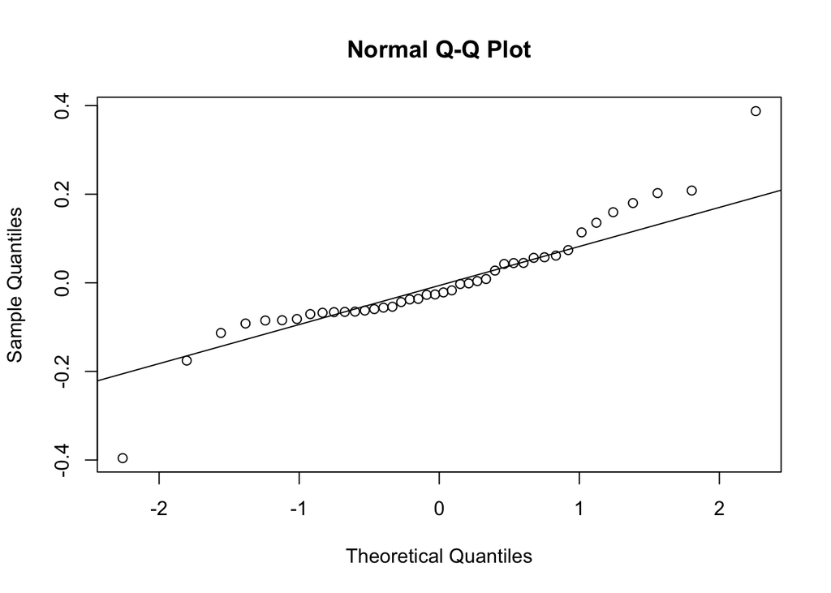

```r
model2_fatC<- lmer(bird_meta_qmr$fat_corrected_mean~bird_meta_qmr$Sex + bird_meta_qmr$Treatment*bird_meta_qmr$Timepoint+(1|bird_meta_qmr$ID))

qqnorm(resid(model2_fatC))
qqline(resid(model2_fatC))
```

```r
anova(model2_fatC)
```

|  | Sum Sq | Mean Sq | NumDF | DenDF | F value | Pr(>F) |
| --- | --- | --- | --- | --- | --- | --- |
| bird_meta_qmr$Sex | 0.000912897 | 0.000912897 | 1 | 11 | 0.03743023 | 0.8501179 |
| bird_meta_qmr$Treatment | 0.027628741 | 0.027628741 | 1 | 11 | 1.13282223 | 0.3099802 |
| bird_meta_qmr$Timepoint | 0.074866870 | 0.037433435 | 2 | 24 | 1.53483022 | 0.2359072 |
| bird_meta_qmr$Treatment:bird_meta_qmr$Timepoint | 0.093815968 | 0.046907984 | 2 | 24 | 1.92330176 | 0.1679841 |

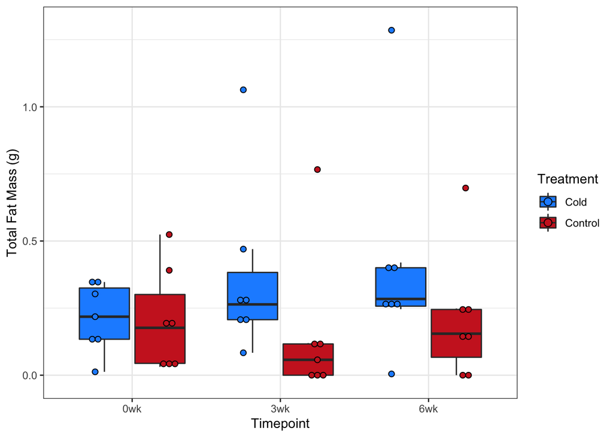

```r
ggplot(bird_meta_qmr, aes(x=Timepoint, y=fat_corrected_mean, fill=Treatment)) + ylab("Total Fat Mass (g)") +
  geom_boxplot(outlier.shape = NA) + scale_fill_manual(values=c("#1E90FF", "#CD2626")) +  geom_dotplot(binaxis='y', stackdir='center',
  position=position_dodge(1), dotsize = 0.5) + theme_bw()
```

```r
pdf(file=paste("Figure_SX_box_plot_QMR_fat_",run_date,".pdf",sep=""),height=6,width=8)
ggplot(bird_meta_qmr, aes(x=Timepoint, y=fat_corrected_mean, fill=Treatment)) + ylab("Total Fat Mass (g)") +
  geom_boxplot(outlier.shape = NA) + scale_fill_manual(values=c("#1E90FF", "#CD2626")) +  geom_dotplot(binaxis='y', stackdir='center',
  position=position_dodge(1), dotsize = 0.5) + theme_bw()
dev.off()
```

```r
AICc(model1_fatC)
```

```
## [1] 24.51647
```

```r
AICc(model2_fatC)
```

```
## [1] 29.81676
```

There does not seem to be any significant effect of treatment, time point, or sex on fat mass, although there is an effect of bird mass on fat mass. Is there an effect of **treatment on lean mass**? We do not include body mass as a covariate in these models since it is not independent of lean mass.

```r
# unsurprisingly, there is a very large effect of bird mass on lean mass.
anova(lmer(bird_meta_qmr$lean_mean~bird_meta_qmr$Mass.SMR +(1|bird_meta_qmr$ID)))
```

|  | Sum Sq | Mean Sq | NumDF | DenDF | F value | Pr(>F) |
| --- | --- | --- | --- | --- | --- | --- |
| bird_meta_qmr$Mass.SMR | 1.480519 | 1.480519 | 1 | 34.4079 | 95.78145 | 1.780136e-11 |

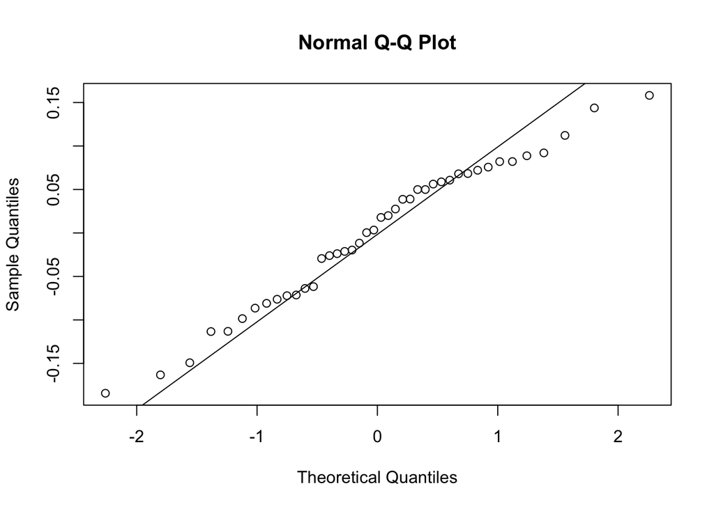

```r
model1_leanC<- lmer(bird_meta_qmr$lean_mean~bird_meta_qmr$Treatment*bird_meta_qmr$Timepoint+(1|bird_meta_qmr$ID))

qqnorm(resid(model1_leanC))
qqline(resid(model1_leanC))
```

```r
anova(model1_leanC) # sig. timepoint, and timepointxtreatment
```

|  | Sum Sq | Mean Sq | NumDF | DenDF | F value | Pr(>F) |
| --- | --- | --- | --- | --- | --- | --- |
| bird_meta_qmr$Treatment | 0.01265853 | 0.01265853 | 1 | 12 | 1.062459 | 3.229832e-01 |
| bird_meta_qmr$Timepoint | 0.28210000 | 0.14105000 | 2 | 24 | 11.838641 | 2.647262e-04 |
| bird_meta_qmr$Treatment:bird_meta_qmr$Timepoint | 0.86562910 | 0.43281455 | 2 | 24 | 36.327092 | 5.493980e-08 |

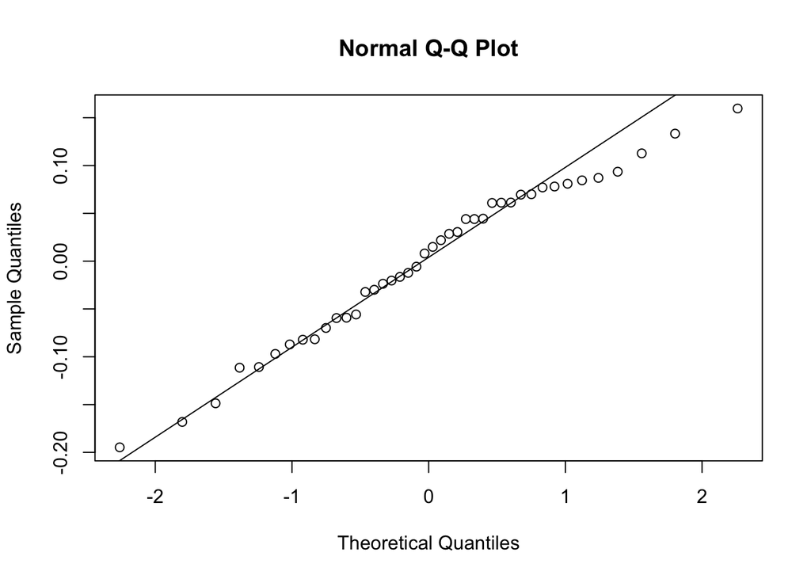

```r
model2_leanC<- lmer(bird_meta_qmr$lean_mean~bird_meta_qmr$Sex + bird_meta_qmr$Treatment*bird_meta_qmr$Timepoint+(1|bird_meta_qmr$ID))

qqnorm(resid(model2_leanC))
qqline(resid(model2_leanC))
```

```r
anova(model2_leanC) # sig. mass, timepoint, and timepointxtreatment
```

|  | Sum Sq | Mean Sq | NumDF | DenDF | F value | Pr(>F) |
| --- | --- | --- | --- | --- | --- | --- |
| bird_meta_qmr$Sex | 0.199047713 | 0.199047713 | 1 | 11.00071 | 16.7061861 | 1.797457e-03 |
| bird_meta_qmr$Treatment | 0.001217392 | 0.001217392 | 1 | 11.00071 | 0.1021764 | 7.552218e-01 |
| bird_meta_qmr$Timepoint | 0.282100000 | 0.141050000 | 2 | 23.99975 | 11.8384055 | 2.647638e-04 |
| bird_meta_qmr$Treatment:bird_meta_qmr$Timepoint | 0.865629101 | 0.432814550 | 2 | 23.99975 | 36.3263676 | 5.495399e-08 |

```r
AICc(model1_leanC) # 29.26664
```

```
## [1] 29.26664
```

```r
AICc(model2_leanC) # 22.61457
```

```
## [1] 22.61457
```

```r
pairs(emmeans(model2_leanC, ~Treatment*Timepoint), adjust="BH")
```

```
##  contrast                  estimate     SE df t.ratio p.value
##  Cold 0wk - Control 0wk    -0.29372 0.2297 12  -1.279  0.4223
##  Cold 0wk - Cold 3wk       -0.29476 0.0583 24  -5.052  0.0003
##  Cold 0wk - Control 3wk    -0.19325 0.2297 12  -0.841  0.5682
##  Cold 0wk - Cold 6wk       -0.55143 0.0583 24  -9.451  <.0001
##  Cold 0wk - Control 6wk    -0.14372 0.2297 12  -0.626  0.6268
##  Control 0wk - Cold 3wk    -0.00104 0.2297 12  -0.005  0.9965
##  Control 0wk - Control 3wk  0.10048 0.0583 24   1.722  0.2532
##  Control 0wk - Cold 6wk    -0.25771 0.2297 12  -1.122  0.4731
##  Control 0wk - Control 6wk  0.15000 0.0583 24   2.571  0.0629
##  Cold 3wk - Control 3wk     0.10152 0.2297 12   0.442  0.7140
##  Cold 3wk - Cold 6wk       -0.25667 0.0583 24  -4.399  0.0010
##  Cold 3wk - Control 6wk     0.15104 0.2297 12   0.658  0.6268
##  Control 3wk - Cold 6wk    -0.35818 0.2297 12  -1.559  0.3105
##  Control 3wk - Control 6wk  0.04952 0.0583 24   0.849  0.5682
##  Cold 6wk - Control 6wk     0.40771 0.2297 12   1.775  0.2532
##
## Results are averaged over the levels of: Sex
## Degrees-of-freedom method: kenward-roger
## P value adjustment: BH method for 15 tests
```

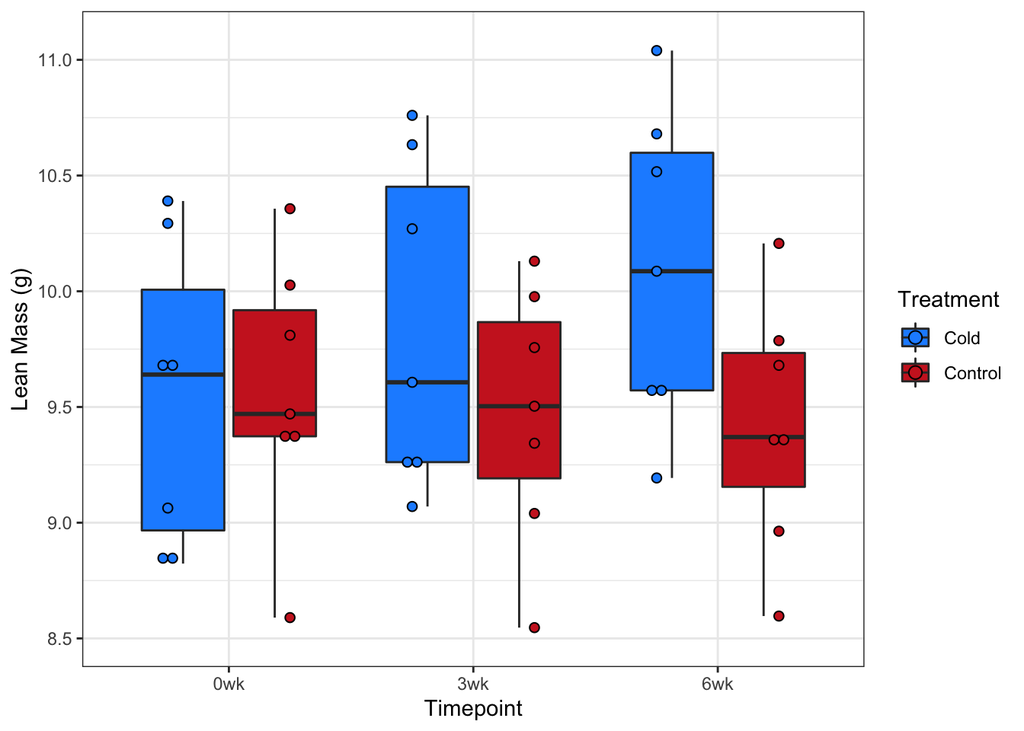

```r
ggplot(bird_meta_qmr, aes(x=Timepoint, y=lean_mean, fill=Treatment)) +
  geom_boxplot(outlier.shape = NA) + scale_fill_manual(values=c("#1E90FF", "#CD2626")) +  geom_dotplot(binaxis='y', stackdir='center',
  position=position_dodge(1), dotsize = 0.5) + ylab("Lean Mass (g)") + theme_bw()
```

```r
pdf(file=paste("Figure_2_box_plot_QMR_lean_",run_date,".pdf",sep=""),height=6,width=8)
ggplot(bird_meta_qmr, aes(x=Timepoint, y=lean_mean, fill=Treatment)) +
  geom_boxplot(outlier.shape = NA) + scale_fill_manual(values=c("#1E90FF", "#CD2626")) +  geom_dotplot(binaxis='y', stackdir='center',
  position=position_dodge(1), dotsize = 0.5) + ylab("Lean Mass (g)") + theme_bw()
dev.off()
```

# Trait correlations

What are the correlations amongst phenotypes?

```r
cor.test(bird_meta$BMR, bird_meta$VO2max) # uncorrected values are sig. (0.0356) correlated (0.3252083),
```

```
##
##  Pearson's product-moment correlation
##
## data:  bird_meta$BMR and bird_meta$VO2max
## t = 2.175, df = 40, p-value = 0.0356
## alternative hypothesis: true correlation is not equal to 0
## 95 percent confidence interval:
##  0.02361068 0.57254843
## sample estimates:
##       cor
## 0.3252083
```

```r
cor.test(bird_meta$BMR.perGram, bird_meta$VO2max.perGram) # but mass-corrected values are not (0.5335, 0.09883)
```

```
##
##  Pearson's product-moment correlation
##
## data:  bird_meta$BMR.perGram and bird_meta$VO2max.perGram
## t = 0.62817, df = 40, p-value = 0.5335
## alternative hypothesis: true correlation is not equal to 0
## 95 percent confidence interval:
##  -0.2114475  0.3910209
## sample estimates:
##        cor
## 0.09883555
```

```r
cor.test(bird_meta_qmr$VO2max,bird_meta_qmr$lean_mean) # sig at 0.001947, 0.464397 cor
```

```
##
##  Pearson's product-moment correlation
##
## data:  bird_meta_qmr$VO2max and bird_meta_qmr$lean_mean
## t = 3.3164, df = 40, p-value = 0.001947
## alternative hypothesis: true correlation is not equal to 0
## 95 percent confidence interval:
##  0.1868366 0.6732961
## sample estimates:
##      cor
## 0.464397
```

```r
cor.test(bird_meta_qmr$Mass.SMR,bird_meta_qmr$lean_mean) # sig at 1.991e-14, 0.8787999 cor
```

```
##
##  Pearson's product-moment correlation
##
## data:  bird_meta_qmr$Mass.SMR and bird_meta_qmr$lean_mean
## t = 11.647, df = 40, p-value = 1.991e-14
## alternative hypothesis: true correlation is not equal to 0
## 95 percent confidence interval:
##  0.7843696 0.9334197
## sample estimates:
##       cor
## 0.8787999
```

```r
cor.test(bird_meta_qmr$VO2max,bird_meta_qmr$fat_corrected_mean) # not sig at 0.0797, 0.2734774 cor
```

```
##
##  Pearson's product-moment correlation
##
## data:  bird_meta_qmr$VO2max and bird_meta_qmr$fat_corrected_mean
## t = 1.7982, df = 40, p-value = 0.0797
## alternative hypothesis: true correlation is not equal to 0
## 95 percent confidence interval:
##  -0.03321474  0.53309847
## sample estimates:
##       cor
## 0.2734774
```

```r
cor.test(bird_meta_qmr$BMR,bird_meta_qmr$lean_mean) # sig at 0.005911, 0.4177394 cor
```

```
##
##  Pearson's product-moment correlation
##
## data:  bird_meta_qmr$BMR and bird_meta_qmr$lean_mean
## t = 2.9079, df = 40, p-value = 0.005911
## alternative hypothesis: true correlation is not equal to 0
## 95 percent confidence interval:
##  0.1303589 0.6403671
## sample estimates:
##       cor
## 0.4177394
```

We find that BMR and SMR are sig. correlated with no mass correction, but are not sig. correlated on a per gram measure. We also find that lean mass is highly sig. correlated with SMR and with BMR. Overall fat is not significantly correlated with SMR, although it is marginal.